# rodeo: Basic Usage and Sample Applications

david.kneis @ tu-dresden.de

2016-11-26

# 1 Main features of `rodeo`

The `rodeo` package facilitates the implementation of ODE-based models in R. Such models describe the dynamics of a set of state variables by simultaneously integrating the corresponding differential equations. The package is particularly useful in conjunction with the R packages [`deSolve`](http://cran.r-project.org/package=deSolve) and [`rootSolve`](http://cran.r-project.org/package=rootSolve). The latter provide numerical solvers for initial-value problems and steady-state estimation. The advantages from using `rodeo` are:

- The model is formulated independent from source code to facilitate portability, re-usability, and documentation. Specifically, the model has to be set-up using the well-established [Peterson matrix notation](http://en.wikipedia.org/wiki/Petersen_matrix). All ingredients of a model (i. e. the ODE’s right hand sides, declarations, and documentation) are in tabular form and they can be imported from delimited text files or spreadsheets.
- Owing to the matrix notation, redundant terms are largely eliminated from the differential equations. This contributes to comprehensibility and increases computational efficiency. The stoichiometry matrix can also be visualized to better communicate the model to other modelers or end users.
- `rodeo` provides a code generator which supports R and Fortran as target languages. Using compiled Fortran can speed up numerical integration by 1 or 2 orders of magnitude (compared to plain R).
- Code can be generated for an arbitrary number of computational boxes (e. g. control volumes in a spatially discretized model). This allows even partial differential equations (e. g. reactive transport problems) to be tackled after appropriate semi-discretization. The latter strategy is known as the [method-of-lines](http://en.wikipedia.org/wiki/Method_of_lines).

# 2 Example ODE system

In the subsequent sections, the package’s functioning is illustrated with a simple model of bacteria growth in a continuous flow stirred tank reactor (figure below). It is assumed that the bacteria grow on a single resource (e. g. a source of organic carbon) which is imported via the reactor’s inflow. Due to mixing, the reactors contents is spatially homogeneous, hence the density of bacteria as well as the concentration of the substrate are scalars.

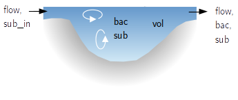

Changes in bacteria density are due to (1) resource-limited growth and (2) wash-out from the reactor (inflow is assumed to be sterile). The substrate concentration is controlled by (1) the inflow as well as (2) the consumption by bacteria. A classical Monod term was used to model the resource dependency of bacteria growth. For the sake of simplicity, the external forcings (i. e. flow rate and substrate load) are held constant and the reactor’s volume is a parameter rather than a state variable.

The governing differential equations are

$\frac{d}{d t}bac = \color{blue}{mu * \frac{sub}{sub+half} * bac} + \color{red}{\frac{flow}{vol}} * (0-bac)$

$\frac{d}{d t}sub = -\frac{1}{yield} * \color{blue}{mu * \frac{sub}{sub+half} * bac} + \color{red}{\frac{flow}{vol}} * (sub_{in}-sub)$

where redundant terms are displayed in identical colors (all identifiers are explained in tables below). For use with `rodeo`, the equations must be split up into a vector of process rates ($r$) and a matrix of stoichiometric factors ($S$) so that the product of the two yields the vector of the state variables’ derivatives with respect to time ($\dot{y}$). Note that

$\dot{y} = r * S$

is the same as

$\dot{y} = S^T * r$

The vector $r$ and the matrix $S$, together with a declaration of all identifiers appearing in the expressions, can conveniently be stored in tables, i.e. R data frames. Appropriate data frames are shipped with the package and can be loaded with the R function `data`. Their contents is displayed below:

Data set `vars`: Declaration of state variables.

| name | unit | description |
| --- | --- | --- |
| bac | mg/ml | bacteria density |
| sub | mg/ml | substrate concentration |

Data set `pars`: Declaration of parameters.

| name | unit | description |
| --- | --- | --- |
| mu | 1/hour | intrinsic bacteria growth rate |
| half | mg/ml | half saturation concentration of substrate |
| yield | mg/mg | biomass produced per amount of substrate |
| vol | ml | volume of reactor |
| flow | ml/hour | rate of through-flow |
| sub_in | mg/ml | substrate concentration in inflow |

Data set `funs`: Declaration of functions referenced at the ODE’s right hand sides.

| name | unit | description |
| --- | --- | --- |
| monod | - | monod expression for resource limitation |

Data set `pros`: Definition of process rates.

| name | unit | description | expression |
| --- | --- | --- | --- |
| growth | mg/hour | bacteria growth | mu * monod(sub, half) * bac |
| inout | 1/hour | water in-/outflow | flow/vol |

Data set `stoi`: Definition of stoichiometric factors providing the relation between processes and state variables. Note the (optional) use of a tabular layout instead of the more common matrix layout.

| variable | process | expression |
| --- | --- | --- |
| bac | growth | 1 |
| bac | inout | -bac |
| sub | growth | -1 / yield |
| sub | inout | (sub_in - sub) |

# 3 Basic use

## 3.1 Creating a `rodeo` model object

We start by loading packages and the example data tables whose contents was shown in the above tables.

```r
library(deSolve)
library(rodeo)
data(vars, pars, pros, funs, stoi)
```

Then, a new object is created with the `new` method of the R6 class system. This requires us to supply the name of the class, data frames for initialization, as well as the spatial dimensions. Here, we create a single-box model (one dimension with no subdivision).

```r
model <- rodeo$new(vars=vars, pars=pars, funs=funs,
  pros=pros, stoi=stoi, dim=c(1))
```

To inspect the object’s contents, we can use the following:

```r
print(model)                   # Displays object members (output not shown)
print(model$stoichiometry())   # Shows stoichiometry as a matrix
```

## 3.2 Defining functions and assigning data

In order to work with the object, we need to define functions that are referenced in the process rate expressions or stoichiometric factors (i. e. the ODEs’ right hand sides). For non-autonomous models, this includes the definition of forcings which are functions of a special argument with the reserved name ‘time’ (details follow in a separate section on forcings).

For the bacteria growth example, we only need to implement a simple [Monod function](https://en.wikipedia.org/wiki/Monod_equation).

```r
monod <- function(c, h) { c / (c + h) }
```

We also need to assign values to parameters and state variables (initial values) using the dedicated class methods `setPars` and `setVars`. Since we deal with a single-box model, parameters and initial values can be stored in ordinary *named* vectors.

```r
model$setVars(c(bac=0.01, sub=0))
model$setPars(c(mu=0.8, half=0.1, yield= 0.1, vol=1000, flow=50, sub_in=1))
```

## 3.3 Computing the stoichiometry matrix

Having defined all functions and having set the values of variables and parameters, one can compute the stoichiometric factors. In general, explicitly computing these factors is not necessary, it may be helpful in debugging however. To do so, the `stoichiometry` class method needs to be supplied with the index of the spatial box (only relevant for multi-box models) as well as the time of interest (in the case of non-autonomous models).

```r
m <- model$stoichiometry(box=1, time=0)
print(signif(m, 3))
```

```
##          bac sub
## growth  1.00 -10
## inout  -0.01   1
```

The stoichiometry matrix is also a good means to communicate a model because it shows the interactions between processes and variables in a concise way. How the stoichiometry matrix can be visualized graphically is demonstrated in a dedicated section below.

## 3.4 Generating source code for numerical solvers

In order to use the model for simulation, we need to generate source code to be passed to numerical solvers. Specifically, the generated function code shall return the derivatives of the state variables with respect to time plus additional diagnostic information (here: the process rates).

After generating the code, we need to make it executable. In R, we can use a combination of `eval` and `parse`. Alternatively, the generated code could be exported to a file using `write` and then loaded with `source`. The latter method allows for inspection of the generated code which may be helpful in debugging.

```r
code <- model$generate(name="derivs",lang="r")
derivs <- eval(parse(text=code))
```

## 3.5 Solving the ODE system

We are now ready to compute the evolution of the state variables over time by means of numerical integration. Note that the initial values (argument `y` of `deSolve::ode`) and parameters (argument `p`) are set to the output of the model object’s `getVars` and `getPars` methods, respectively. This is to make sure that the order of values in the two arrays is consistent with the generated code.

```r
out <- deSolve::ode(y=model$getVars(useNames=TRUE), times=0:96,
  func=derivs, parms=model$getPars())
colnames(out) <- c("time", model$namesVars(), model$namesPros())
layout(matrix(1:4, nrow=2, byrow=TRUE))
plot(out, mfrow=NULL)  # plot method for 'deSolve' objects
layout(1)
```

The graphical output of the above code is displayed below (top row: state variables, bottom row: process rates).

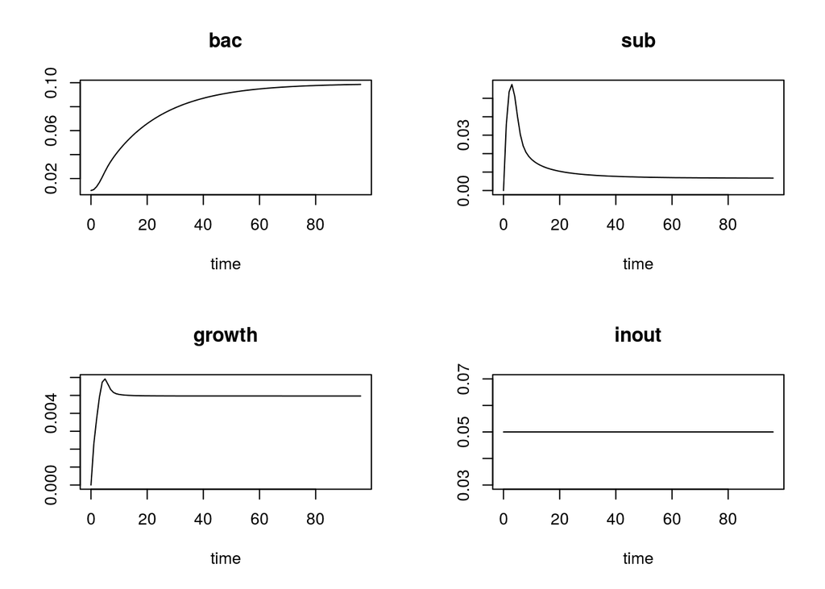

# 4 Advanced topics

## 4.1 Multi-box models (spatial discretization)

A single-box model has been considered so far. We will now extend the model for multiple boxes, i. e. we model a set of reactors. To keep it simple, we consider just two boxes and we assume that the dynamics in the reactors is independent of each other (like in an experiment with two replicates).

First, we need to create a model object with the desired number of boxes in the respective dimensions. In this example, we deal with just one dimension.

```r
library(deSolve)
library(rodeo)
data(vars, pars, pros, funs, stoi)
```

```r
nBox <- 2
model <- rodeo$new(vars=vars, pars=pars, funs=funs,
  pros=pros, stoi=stoi, dim=c(nBox))
```

Second, the code needs to be re-generated to reflect the altered number of boxes.

```r
code <- model$generate(name="derivs",lang="r")
derivs <- eval(parse(text=code))
```

```r
monod <- function(c, h) { c / (c + h) }
```

Third, initial values and parameters need to be specified as arrays now (instead of vectors) to account for the spatial discretization. For a model with one spatial dimension, we must use two-dimensional arrays, i. e. matrices. Here, we initialize every modeled reactor with a different bacteria density but parameter values are kept identical for all reactors.

```r
v <- cbind(bac= seq(from=0.01, to=0.2, length.out=nBox), sub= rep(0, nBox))
model$setVars(v)
p <- c(mu=0.8, half=0.1, yield= 0.1, vol=1000, flow=50, sub_in=1)
p <- matrix(rep(p, each=nBox), nrow=nBox, dimnames=list(NULL, names(p)))
model$setPars(p)
```

Finally, the integration method is called as usual.

```r
out <- ode(y=model$getVars(useNames=TRUE), times=0:96, func=derivs, parms=model$getPars())
layout(matrix(1:(model$lenVars()*nBox), nrow=nBox, byrow=TRUE))
plot(out, which=1:(model$lenVars()*nBox), mfrow=NULL)
layout(1)
```

In the graphical output of the above code, the state variables are organized in rows, and each column refers to a spatial box (see suffix in figure titles).

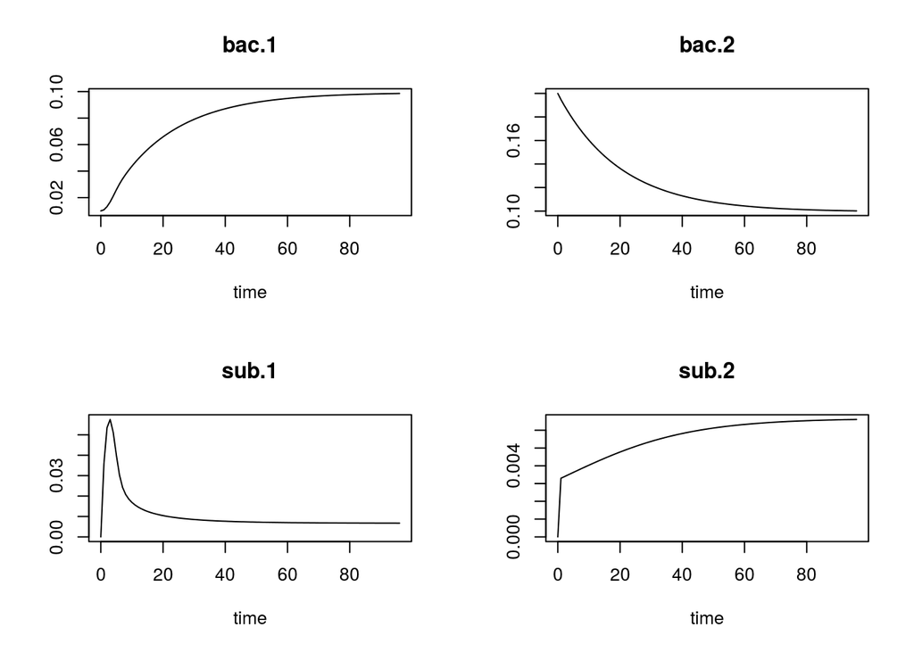

Note the convention regarding the storage of state variables in multi-box models. Generally, the values of neighboring boxes of a *particular* state variable are stored in the respective vector as neighboring elements. For example, in a 1-dimensional model with 3 boxes and two state variables A and B, the layout of the states vector is A.1, A.2, A.3, B.1, B.2, B.3 (instead of A.1, B.1, A.2, …). This convention applies to the output of the numerical solvers as well, i. e. the columns of the output matrix returned from the [`deSolve`](http://cran.r-project.org/package=deSolve) integrators follows the described layout.

## 4.2 Maximizing performance through Fortran

As the number of simultaneous ODE increases and the right hand sides become more complex, computation times begin to matter. This is especially so in case of stiff systems of equations. In those time-critical cases, it is recommended to generate source code for a compilable language. The language supported by `rodeo` is Fortran. Fortran was chosen because of its superior array support (compared to C) and for compatibility with existing numerical libraries.

One could use the low-level method

```r
code <- model$generate(name="derivs",lang="f95")    # not required for typical uses
```

to generate a function that computes the state variables’ derivatives in Fortran. However, the interface of the generated function is optimized for universality. In order to use the generated code with the numerical solvers from [`deSolve`](http://cran.r-project.org/package=deSolve) or [`rootSolve`](http://cran.r-project.org/package=rootSolve), a specialized wrapper is required.

To make the use of Fortran as simple as possible, `rodeo` provides a high-level class method `compile` which combines

1. generation of the basic Fortran code via the `generate` method (see above),
2. generation of the required wrapper for compatibility with `deSolve` and `rootSolve`,
3. compilation of all Fortran sources into a shared library (based on the command `R CMD SHLIB`)

```r
lib <- model$compile(sources="fortran/functionsCode.f95")
```

The `compile` method takes as argument the name of a file holding the Fortran implementation of functions being referenced in the particular model’s mathematical expressions. This argument can actually be a vector if the source code is split across several files. Consult the section on Fortran functions for coding guidelines and take a look at the collection of examples.

The return value of `compile` is a named vector of character strings holding the name of the generated shared library (in element `libName`), the full file path of the library (in element `libFile`) as well as the name of the callable subroutine within that library (in element `libFunc`). The library must be loaded and unloaded with `dyn.load` and `dyn.unload`, respectively.

A suitable Fortran implementation of the functions used in the example (contents of file ‘fortran/functionsCode.f95’) is shown below. Note that all the functions are collected in a single Fortran module with implicit typing turned off. The name of this module must be `'functions'` and it cannot be changed. Note that a Fortran module can import other modules which helps to structure more complex source codes. Also note that the user-supplied source files need to reside in directories with write-access to allow the creation of intermediate files during compilation.

```
! This is file 'functionsCode.f95'
 module functions
   implicit none
   contains

   double precision function monod(c, h)
     double precision, intent(in):: c, h
     monod= c / (c + h)
   end function

 end module
```

The complete code to run the model from the previous section using Fortran-based code is given below. Note the additional arguments `dllname` and `nout` being passed to the numerical solver (for details consult the `deSolve` help page for method `lsoda`). It is especially important to pass the correct value to `nout`: In case of `rodeo`-based models, this must be the number of processes multiplied with the total number of boxes. Disregard of this may trigger segmentation faults that make R crash.

```r
library(deSolve)
library(rodeo)
data(vars, pars, pros, funs, stoi)
```

```r
nBox <- 2
model <- rodeo$new(vars=vars, pars=pars, funs=funs,
  pros=pros, stoi=stoi, dim=c(nBox))
```

```r
v <- cbind(bac= seq(from=0.01, to=0.2, length.out=nBox), sub= rep(0, nBox))
model$setVars(v)
p <- c(mu=0.8, half=0.1, yield= 0.1, vol=1000, flow=50, sub_in=1)
p <- matrix(rep(p, each=nBox), nrow=nBox, dimnames=list(NULL, names(p)))
model$setPars(p)
```

```r
lib <- model$compile(sources="fortran/functionsCode.f95")
```

```r
dyn.load(lib["libFile"])
out <- ode(y=model$getVars(useNames=TRUE), times=0:96,
  func=lib["libFunc"], parms=model$getPars(), dllname=lib["libName"],
  nout=model$lenPros()*prod(model$getDim()))
layout(matrix(1:(model$lenVars()*nBox), nrow=nBox, byrow=TRUE))
plot(out, which=1:(model$lenVars()*nBox), mfrow=NULL)
layout(1)
dyn.unload(lib["libFile"])
invisible(file.remove(lib["libFile"]))
```

The output of the above code is displayed below. It should be identical to the above output from the R-based code.

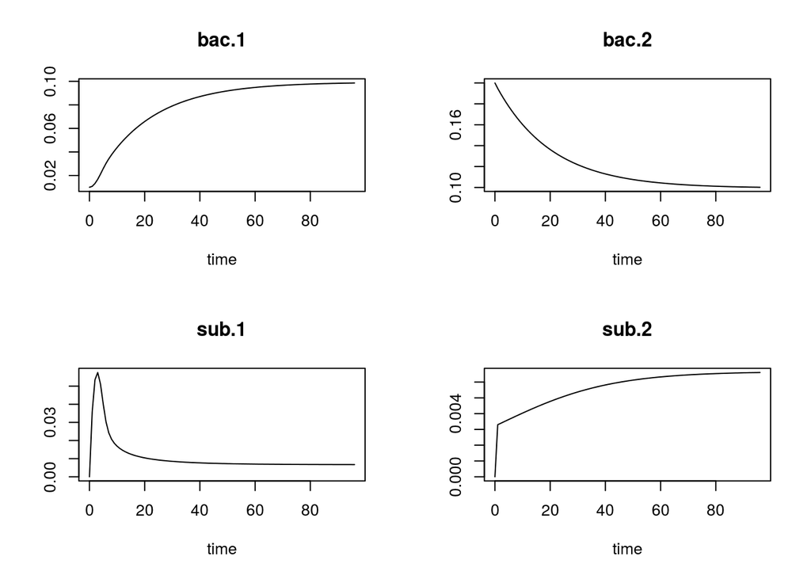

## 4.3 Forcing functions (time-varying parameters)

In general, there are two options for dealing with time-variable forcings:

**Functions-of-time:** For this approach one needs to define the forcings as functions of a formal argument that represents time. In `rodeo`, the actual argument must have the reserved name `time`. The approach is handy if the forcings can be approximated by parametric functions (like the seasonal cycle of extra-terrestrial solar radiation, for example). It can also be used with tabulated time series data, but this requires some extra coding. In any case, it is essential to restrict the integration step size of the solver (e.g. using the `hmax` argument of `deSolve::lsoda`) so that short-term variations in the forcings cannot be ‘missed’.

**Stop-and-go:** For this approach forcings are implemented as normal parameters. To allow for their variation in time, the ODE solver is interrupted every time when the forcing data change. The solver is then re-started with the updated parameters (i.e. forcing data) using the states output from the previous call as initial values. Hence, the calls to the ODE solver must be embedded within a loop over time. With this approach, setting a limit on the solver’s integration step size (through argument `hmax`) is not required since the solver is interrupted at the ‘critical times’ anyway.

In real-world applications, the ‘stop-and-go’ approach is often simpler to use and the overhead due to interruption and re-start of the solvers seems to be rather small. It also facilitates the generation of useful trace-back information in case of exceptions (e.g. due to corrupt time series data).

The remainder of this section demonstrates how the ‘functions-of-time’ approach can be used in Fortran-based models. It is assumed that information on forcings is stored in delimited text files. Such files can be created, for example, with any spreadsheet software, data base system, or R. Assume that we have time series of two meteorological variables exported to a text file ‘meteo.txt’:

```r
dat <- data.frame(time=1:10, temp=round(rnorm(n=10, mean=20, sd=3)),
  humid=round(runif(10)*100))
write.table(x=dat, file="tmp/meteo.txt", col.names=TRUE,
  row.names=FALSE, sep="\t", quote=FALSE)
print(dat)
```

```
##    time temp humid
## 1     1   12    75
## 2     2   24    78
## 3     3   21    15
## 4     4   25    95
## 5     5   19    16
## 6     6   20    37
## 7     7   20    10
## 8     8   19    36
## 9     9   20    71
## 10   10   19    30
```

```r
dat <- data.frame(name=c("temp","humid"),
  column=c("temp","humid"), file="tmp/meteo.txt", mode=-1, default=FALSE)
code <- forcingFunctions(dat)
write(x=code, file="tmp/forc.f95")
```

In order to use the generated code, it is necessary to

1. write it to disk (e. g. using `write` as shown above),
2. declare all forcings as functions in `rodeo`’s respective input table,
3. insert the statement `use forcings` at the top (e. g. line 2) of the Fortran module `'functions'`,
4. pass the generated file to the `compile` method along with all other Fortran source files.

The following Fortran code demonstrates how the user-defined forcings can be tested/debugged outside the `rodeo` environment. The shown utility program can be compiled, for example, using a command like

`gfortran <generated_module_file> <file_with_program> -o test`

Note that the subroutines `rwarn` and `rexit` are available automatically if a shared library is build with the `compile` class method (or directly with `R CMD SHLIB`), i. e. they shouldn’t be defined by the user for normal applications of `rodeo`.

```
 ! auxiliary routines for testing outside R
 subroutine rwarn(x)
   character(len=*),intent(in):: x
   write(*,*)x
 end subroutine

 subroutine rexit(x)
   character(len=*),intent(in):: x
   write(*,*)x
   stop
 end subroutine

 ! test program
 program test
 use forcings  ! imports generated module with forcing functions

 implicit none

 integer:: i
 double precision, dimension(5):: times= &
   dble((/ 1., 1.5, 2., 2.5, 3. /))

 do i=1, size(times)
   write(*,*) times(i), temp(times(i)), humid(times(i))
 end do
 end program
```

## 4.4 Generating model documentation

### 4.4.1 Exporting formatted tables

One can use e. g. the package’s `exportDF` to export the object’s basic information in a format which is suitable for inclusion in HTML or LaTeX documents. The code section

```r
# Select columns to export
df <- model$getVarsTable()[,c("tex","unit","description")]
# Define formatting functions
bold <- function(x){paste0("\\textbf{",x,"}")}
mathmode <- function(x) {paste0("$",x,"$")}
# Export
tex <- exportDF(x=df, tex=TRUE,
  colnames=c(tex="symbol"),
  funHead=setNames(replicate(ncol(df),bold),names(df)),
  funCell=list(tex=mathmode)
)
cat(tex)
```

generates the following LaTeX code

```
  \begin{tabular}{lll}\hline
    \textbf{symbol} & \textbf{unit} & \textbf{description} \\ \hline
    $bac$ & mg/ml & bacteria density \\
    $sub$ & mg/ml & substrate concentration \\ \hline
  \end{tabular}
```

holding tabular information on the model’s state variables. To include the result in a document one needs to write the generated LaTeX code to a file for import with either the `input` or `include` directive. Things are even simpler if the Sweave pre-processor is used which allows the above R code to be embedded in LaTeX directly between the special markers `<<echo=FALSE, results=tex>>=` and `@`.

Alternatively, a markdown compatible version can be generated and used with the `kable` function from the `knitr` package. This will work with html, pdf or word processor formats. The following code section to create a table of the model’s state variables

```r
knitr::kable(model$getVarsTable()[,c("name","unit","description")])
```

produces the result:

| name | unit | description |
| --- | --- | --- |
| bac | mg/ml | bacteria density |
| sub | mg/ml | substrate concentration |

### 4.4.2 Visualizing the stoichiometry matrix

A graphical representation of the stoichiometry matrix is often a good means to communicate a model. To create such a graphics, one typically wants to replace the stoichiometry factors’ numeric values by symbols encoding their sign only.

#### 4.4.2.1 Plain R graphics

One can use the class method `plotStoichiometry` to visualize the matrix using standard R graphics as demonstrated below. This creates a matrix of triangle symbols where the orientation indicates whether the value of a state variable increases (upward) or decreases (downward) due to the action of a particular process.

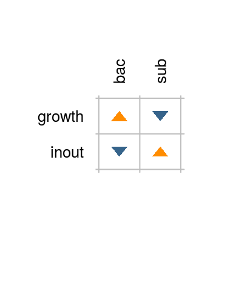

```r
model$plotStoichiometry(box=1, time=0, cex=0.8)
```

In practice, one needs to fiddle around a bit with the dimensions of the plot and the font size to get an acceptable scaling of symbols and text. Also, it is hardly possible to nicely display row and column names containing special formatting like sub- or superscripts.

#### 4.4.2.2 LaTeX documents

The following example generates suitable LaTeX code to display a symbolic stoichiometry matrix (as a table, not a graphics).

```r
signsymbol <- function(x) {
  if (as.numeric(x) > 0) return("\\textcolor{red}{$\\blacktriangle$}")
  if (as.numeric(x) < 0) return("\\textcolor{blue}{$\\blacktriangledown$}")
  return("")
}
rot90 <- function(x) { paste0("\\rotatebox{90}
  {$",gsub(pattern="*", replacement="\\cdot ", x=x, fixed=TRUE),"$}") }
m <- model$stoichiometry(box=1, time=0)
tbl <- cbind(data.frame(process=rownames(m), stringsAsFactors=FALSE),
  as.data.frame(m))
tex <- exportDF(x=tbl, tex=TRUE,
  colnames= setNames(c("",model$getVarsTable()$tex[match(colnames(m),
    model$getVarsTable()$name)]), names(tbl)),
  funHead= setNames(replicate(ncol(m),rot90), colnames(m)),
  funCell= setNames(replicate(ncol(m),signsymbol), colnames(m)),
  lines=TRUE
)
tex <- paste0("%\n% THIS IS A GENERATED FILE\n%\n", tex)
# write(tex, file="stoichiometry.tex")
```

The contents of the variable `tex` must be written to a text file and this file can then be imported in LaTeX with the `input` directive.

#### 4.4.2.3 HTML documents

The following example generates suitable code for inclusion in HTML documents.

```r
signsymbol <- function(x) {
  if (as.numeric(x) > 0) return("&#9651;")
  if (as.numeric(x) < 0) return("&#9661;")
  return("")
}
m <- model$stoichiometry(box=1, time=0)
tbl <- cbind(data.frame(process=rownames(m), stringsAsFactors=FALSE),
  as.data.frame(m))
html <- exportDF(x=tbl, tex=FALSE,
  colnames= setNames(c("Process",model$getVarsTable()$html[match(colnames(m),
    model$getVarsTable()$name)]), names(tbl)),
  funCell= setNames(replicate(ncol(m),signsymbol), colnames(m))
)
html <- paste("<html>", html, "</html>", sep="\n")
# write(html, file="stoichiometry.html")
```

To test this, one needs to write the contents of the variable `html` to a text file and open that file in a web browser. In some cases, automatic conversion of the generated HTML into true graphics formats may be possible, e. g. using auxiliary (Linux) tools like ‘html2ps’ and ‘convert’.

#### 4.4.2.4 Markdown documents

A markdown compatible version can be generated with the `kable` function from package `knitr`.

```r
signsymbol <- function(x) {
  if (as.numeric(x) > 0) return("$\\color{red}{\\blacktriangle}$")
  if (as.numeric(x) < 0) return("$\\color{blue}{\\blacktriangledown}$")
  return("")
}
m <- model$stoichiometry(box=1, time=0)
m <- apply(m, MARGIN = c(1, 2), signsymbol)
knitr::kable(m)
```

|  | bac | sub |
| --- | --- | --- |
| growth | $\color{red}{\blacktriangle}$ | $\color{blue}{\blacktriangledown}$ |
| inout | $\color{blue}{\blacktriangledown}$ | $\color{red}{\blacktriangle}$ |

# 5 Practical issues

## 5.1 Managing tabular input data

`rodeo`’s tabular input data are typically held in either plain text files or spreadsheets. The two alternatives have their own pros and cons summarized in the table below.

| Feature | Delimited text | Spreadsheet |
| --- | --- | --- |
| Portability across programs and operating systems | + | (-) |
| Suitability for version control | + | - |
| Editing with regular expressions | + | - |
| Syntax highlight for expressions | (+) | - |
| Display table with proper alignment of columns | - | + |
| View multiple tables at a time | + | (-) |

Practice has shown that it is a good compromise to store the tabular data in delimited text files and to open them either in a spreadsheet program or editor, depending on the particular task. Note that the conventional ‘csv’ format is not recommended since mathematical expressions involving multi-argument functions and text descriptions may contain commas (hence, they need to be quoted). Using TAB-delimited text is probably the best option. It can be copied-and-pasted between text and spreadsheet files. Modern editors can highlight TAB-characters making them distinguishable from ordinary blanks.

## 5.2 Checking the model formulation

Model outputs can be wrong for many reasons, including inadequate process equations, bad inputs, and numerical problems. Thus, minimizing the number of spots where mistakes/errors can hide is important.

One of the few simple means to check the consistency of environmental models is to analyze balances of mass, matter, and/or energy. This can often be accomplished without actual model simulations, just by analyzing the row sums of the stoichiometry matrix. The `rodeo` package provides a method `stoiCheck` to facilitate this and the companion method `stoiCreate` can help to set-up consistent stoichiometric matrices.

## 5.3 Writing `rodeo`-compatible Fortran functions

### 5.3.1 Reference example

As a reference, the following Fortran code can be used (after deletion of line numbers). The code declares a function of two arguments. All identifiers are in uppercase letters just for clarification. Comments have been added to briefly explain the individual statements. In Fortran, comments start with an exclamation mark.

```
1  double precision function FUNCNAME (ARG1, ARG2) ! declare the function
2  implicit none                                   ! force type declarations
3  double precision, intent(in):: ARG1, ARG2       ! declare arguments
4  double precision:: LOCAL                        ! declare local variable
5  double precision, parameter:: CONST=1.d0        ! declare local constant
6  LOCAL= ARG1 * CONST + ARG2                      ! local computation(s)
7  FUNCNAME= LOCAL                                 ! set return value
8  end function                                    ! closes the function
```

For compatibility with `rodeo`, the function result must be a scalar of type `double precision` (a floating point number of typically 8 byte). There are several ways to achieve this but the simplest and recommended syntax is put the type declaration `double precision` right before the function’s name (line 1). Then, the return value must be set by an assignment to the function’s name (line 7). This is best done at a single location in the body code, typically at the very end.

It is a good habit to always put `implicit none` in the first line of the function body (line 2). This is to disable ‘implicit typing’ which is a rather dangerous automatism of data type assignment. With this statement, all arguments (line 3) and any local variables or constants (lines 4 and 5) need to be explicitly declared. As opposed to C or C++, data types of formal arguments cannot be declared in the function interface (line 1), making it necessary to waste some extra lines (line 3). All declarations need to be made at the top of the function’s body right after the `implicit none`.

In `Fortran`, identifier names are not case-sensitive (as opposed to R). This applies to the name of the function itself as well as to the names of arguments and local variables or parameters. Using uppercase names for constants is a widespread habit.

Note: It is actually sufficient to put a single `implicit none` statement at the beginning of the module `'functions'` (see example in the above section on Fortran code generation). Repetition of `implicit none` statements in the individual functions doesn’t do any harm, however.

### 5.3.2 Common Fortran pitfalls

#### 5.3.2.1 Double precision constants

Fortran has several types to represent floating point numbers that vary in precision but `rodeo` generally uses the type `double precision`. Thus, any local variables and parameters should also be declared as `double precision`. To declare a *constant* of this type, e. g. ‘pi’, one needs to use the special syntax `3.1415d0`, i.e. the conventional ‘e’ in scientific notation must be replaced by ‘d’. Do **not** use the alternative syntax `3.1415_8` as it is not portable. Some further examples are shown below. Note the use of the `parameter` keyword informing the compiler that the declared items are constants rather than variables.

```
double precision, parameter:: pi= 3.1415d0, e= 2.7183d0   ! math constants
double precision, parameter:: kilograms_per_gram = 1.d-3  ! 1/1000
double precision, parameter:: distance_to_moon = 3.844d+5 ! 384400 km
```

#### 5.3.2.2 Integers in numeric expressions

It is recommended to avoid integers in arithmetic expressions as the result may be unexpected. Use `double precision` constants instead of `integer` constants or, alternatively, explicitly convert types by means of the `dble` intrinsic function.

```
average= (value1 + value2) / 2d0       ! does not use an integer at all
average= (value1 + value2) / dble(2)   ! explicit type conversion
```

It is often even better not to use any literal constants, leading to a code like

```
double precision, parameter:: TWO= 2.d0
! ... possibly other statements ...
average= (value1 + value2) / TWO
```

#### 5.3.2.3 Long Fortran statements (continuation lines)

Source code lines should not exceed 80 characters (though some Fortran compilers support longer lines). If an expression does not fit on a single line, the ampersand (`&`) must be used to indicate continuation lines. Missing `&` characters are a frequent cause of compile time errors and the respective diagnostic messages are sometimes rather obscure. It is recommended to put the `&` at the end of any unfinished line as in the following example:

```
a = term1 + term2 + &
    term3 + term4 + &
    term5
```

### 5.3.3 More information on Fortran

The code contained in the section on Fortran code generation or the gallery of examples may serve as a starting point. The [Fortran wiki](http://fortranwiki.org/fortran/show/HomePage) is a good source of additional information, also providing links to standard documents, books, etc.

## 5.4 Multi-object models

Real-world applications often require the simulation of multiple interacting compartments. In some cases it may still be possible to handle those systems with a single set of ODE and to properly set up the Jacobian matrix. In many cases, however, it will be easier to work with separate ODE models (one for each compartment) and to allow for inter-model communication at an adequate frequency. The concept of ‘linked sub-models’ can be used with `rodeo` and it is also promoted by the OpenMI initiative (Gregersen, Gijsbers, and Westen 2007). The downsides of the approach are

- a loss of computational efficiency, mainly because the ODE solver needs to re-start frequently,
- a potential loss in accuracy owing to time-step wise decoupling of the equations.

The second aspect is particularly important and, for serious applications, the impact of the chosen frequency of inter-model communication needs to be understood. In general, a more accurate solution can be expected if the frequency of communication is increased.

In spite of the mentioned drawbacks, the concept of linked sub-models remains attractive because

- a modular system is easier to develop, debug, document, and re-use,
- one can link `rodeo`-objects with any ‘foreign’ model objects, which opens the possibility to couple ODE and non-ODE models.

A simple test case demonstrating the linkage of two `rodeo`-objects can be found in a dedicated example section. Note that those parts of `rodeo` targeted at model coupling (e. g. the class method `step`) are under development and details of the implementation may change in the future.

# 6 Further examples

## 6.1 Single-box models

### 6.1.1 Streeter-Phelps like model

#### 6.1.1.1 Problem description

The model is an analog to the classical model of Streeter and Phelps (1925). It simulates aerobic 1st-order decay of organic matter and atmospheric aeration in a mixed tank (see figure below). The tank has neither in- nor outflow. It can either be regarded as an actual tank or as a control volume moving down a river. The model’s two state variables are degradable organic matter (OM) and dissolved oxygen (DO). This is in contrast to the original model of Streeter and Phelps (1925) which considers biochemical oxygen demand, BOD, (rather than OM) and the oxygen deficit (rather than DO).

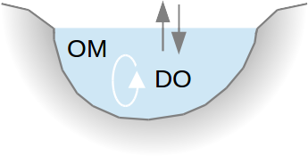

The presented model accounts for the processes of microbial degradation in the simplest possible way. It does not consider oxygen limitation, hence, it returns non-sense if the system goes anaerobic. Furthermore, the model neglects temperature dependence of micribioal activity, it does not distinguish between CBOD and NBOD, the degradation rate constant does not vary over time (meaning that microbes do not reproduce), and there is no interaction between water and sediment, etc.

In this example, integration is performed using generated R code (in contrast to other examples based on Fortran).

#### 6.1.1.2 Tabular model definition

The model’s state variables, parameters, and functions are declared below, followed by the speficition of process rates and stoichiometric factors.

Declaration of state variables (file ‘vars.txt’).

| name | unit | description |
| --- | --- | --- |
| OM | mg/l | Organic matter (as carbon) |
| DO | mg/l | Dissolved oxygen |

Declaration of parameters (file ‘pars.txt’).

| name | unit | description |
| --- | --- | --- |
| kd | 1/day | Degradation rate constant |
| ka | 1/day | Re-aeration rate constant |
| s | mass ratio | g DO consumed per g OM |
| temp | celsius | Temperature |

Declaration of functions (file ‘funs.txt’).

| name | unit | description |
| --- | --- | --- |
| DOsat | mg/l | Oxygen saturation as a function of temperature |

Definition of process rates (file ‘pros.txt’).

| name | unit | description | expression |
| --- | --- | --- | --- |
| degradation | mg/l/d | Decay rate | kd * OM |
| reaeration | mg/l/d | Re-aeration rate | ka * (DOsat(temp)-DO) |

Definition of stoichiometric factors (file ‘stoi.txt’).

| process | OM | DO |
| --- | --- | --- |
| degradation | -1 | -s |
| reaeration | 0 | 1 |

#### 6.1.1.3 Implementation of functions

Since the model is run in pure R, the required function is implemented directly in the R below.

#### 6.1.1.4 R code to run the model

A `rodeo`-based implementation and application of the model is demonstrated by the following R code. It makes use of the tables displayed above.

```r
rm(list=ls())

# Adjustable settings ##########################################################
pars <- c(kd=1, ka=0.5, s=2.76, temp=20)  # parameters
vars <- c(OM=1, DO=9.02)                  # initial values
times <- seq(from=0, to=10, by=1/24)      # times of interest
# End of settings ##############################################################

# Load required packages
library("deSolve")
library("rodeo")

# Initialize rodeo object
rd <- function(f, ...) {read.table(file=f,
  header=TRUE, sep="\t", stringsAsFactors=FALSE, ...) }
model <- rodeo$new(vars=rd("vars.txt"), pars=rd("pars.txt"), funs=rd("funs.txt"),
  pros=rd("pros.txt"), stoi=as.matrix(rd("stoi.txt", row.names="process")),
  asMatrix=TRUE, dim=c(1))

# Assign initial values and parameters
model$setVars(vars)
model$setPars(pars)

# Implement required functions
DOsat <- function(t) {
  14.652 - 0.41022*t + 7.991e-3*(t**2) - 7.7774e-5*(t**3)
}

# Generate code and parse
code <- model$generate(name="derivs", lang="r")
derivs <- eval(parse(text=code))

# Integrate
out <- deSolve::ode(y=model$getVars(), times=times, func=derivs,
  parms=model$getPars())
colnames(out) <- c("days", model$namesVars(), model$namesPros())

# Plot, using the method for objects of class deSolve
plot(out)
```

#### 6.1.1.5 Model output

The output from the above code (displayed below) shows the characteristic sag in the dynamics of dissolved oxygen. Note that the timing of the minimum corresponds to a river station if the simulated tank represents a moving control volume.

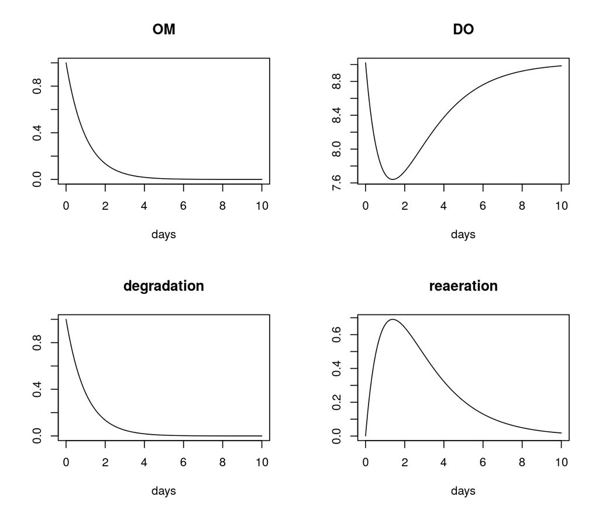

### 6.1.2 Bacteria in a 2-zones stirred tank

#### 6.1.2.1 Problem description

The model simulates the dynamics of bacteria in a continuous-flow system which is subdivided into two tanks. The main tank is directly connected with the system’s in- and outflow. The second tank is connected to the main tank but it does not receive external inflow (see figure below and subsequent tables for a declaration of symbols). Both tanks are assumed to be perfectly mixed. The model accounts for import/export of bacteria and substrate into/from the two tanks. Growth of bacteria in the two tanks is limited by substrate availability according to a [Monod function](https://en.wikipedia.org/wiki/Monod_equation).

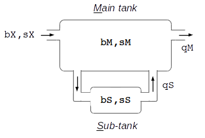

Instead of simulating the system’s dynamics, we analyze steady-state concentrations of bacteria for different choices of the model’s parameters. The parameters whose (combined) effect is examined are:

1. the relative volume of the sub-tank in relation to the system’s total volume (parameter `fS`),
2. the intensity of exchange between the two tanks (parameter `qS`),
3. the growth rate of bacteria (controlled by parameter `mu`).

This kind of sensitivity analysis can be used to gain insight into the fundamental impact of transient storage on bacteria densities. A corresponding real-world systems would be a river section (main tank) that exchanges water with either a lateral pond or the pore water of the hyporheic zone (sub-tanks). Note that, in this model, the sub-tank allocates a *fraction* of the system’s total volume. This is (at least partly) in contrast to the mentioned real systems, where the *total volume increases* with increasing thickness of the hyporheic zone or the size of a lateral pond.

The `runsteady` method from the [`rootSolve`](http://cran.r-project.org/package=rootSolve) package is employed for steady-state computation. Thus, we just perform integration over a time period a sufficient length. While this is not the most efficient strategy it comes with the advantage of guaranteed convergence independent of the assumed initial state.

#### 6.1.2.2 Tabular model definition

The model’s state variables, parameters, and functions are declared below, followed by the speficition of process rates and stoichiometric factors.

Declaration of state variables (file ‘vars.txt’).

| name | unit | description |
| --- | --- | --- |
| bM | mg/ml | Bacteria concentration in main tank |
| bS | mg/ml | Bacteria concentration in sub-tank |
| sM | mg/ml | Substrate concentration in main tank |
| sS | mg/ml | Substrate concentration in sub-tank |

Declaration of parameters (file ‘pars.txt’).

| name | unit | description |
| --- | --- | --- |
| vol | ml | Total volume (main tank + sub-tank) |
| fS | - | Fraction of total volume assigned to sub-tank |
| qM | ml/hour | External in-/outflow to/from main tank |
| qS | ml/hour | Flow rate in sub-tank branch |
| bX | mg/ml | Concentration of bacteria in external inflow to main tank |
| sX | mg/ml | Concentration of substrate in external inflow to main tank |
| mu | 1/hour | Growth rate constant of bacteria |
| yield | mg/mg | Yield coef. (bacteria produced per amount of substrate) |
| half | mg/ml | Half saturation conc. of sustrate for bacteria growth |

Definition of process rates (file ‘pros.txt’).

| name | unit | description | expression |
| --- | --- | --- | --- |
| bLoadX2M | mg/hour | Bacteria import to main tank | qM * bX |
| bLoadM2X | mg/hour | Bacteria export from main tank | qM * bM |
| bLoadM2S | mg/hour | Bacteria import to sub-tank | qS * bM |
| bLoadS2M | mg/hour | Bacteria export from sub-tank | qS * bS |
| sLoadX2M | mg/hour | Substrate import to main tank | qM * sX |
| sLoadM2X | mg/hour | Substrate export from main tank | qM * sM |
| sLoadM2S | mg/hour | Substrate import to sub-tank | qS * sM |
| sLoadS2M | mg/hour | Substrate export from sub-tank | qS * sS |
| bGrowthM | mg/ml/hour | Bacteria gowth in main tank | mu * sM/(sM+half) * bM |
| bGrowthS | mg/ml/hour | Bacteria growth in sub-tank | mu * sS/(sS+half) * bS |

Definition of stoichiometric factors (file ‘stoi.txt’).

| process | bM | bS | sM | sS |
| --- | --- | --- | --- | --- |
| bLoadX2M | 1/(vol*(1-fS)) |  |  |  |
| bLoadM2X | -1/(vol*(1-fS)) |  |  |  |
| bLoadM2S | -1/(vol*(1-fS)) | 1/(vol*fS) |  |  |
| bLoadS2M | 1/(vol*(1-fS)) | -1/(vol*fS) |  |  |
| sLoadX2M |  |  | 1/(vol*(1-fS)) |  |
| sLoadM2X |  |  | -1/(vol*(1-fS)) |  |
| sLoadM2S |  |  | -1/(vol*(1-fS)) | 1/(vol*fS) |
| sLoadS2M |  |  | 1/(vol*(1-fS)) | -1/(vol*fS) |
| bGrowthM | 1 |  | -1/yield |  |
| bGrowthS |  | 1 |  | -1/yield |

#### 6.1.2.3 Implementation of functions

For this model, no functions need to be implemented.

#### 6.1.2.4 R code to run the model

A `rodeo`-based implementation and application of the model is demonstrated by the following R code. It makes use of the tables displayed above.

```r
rm(list=ls())

# Adjustable settings ##########################################################
vars <- c(bM=0, bS=0, sM=0, sS=0)                       # initial values
pars <- c(vol=1000, fS=NA, qM=200, qS=NA,               # fixed parameter values
  bX=1, sX=20, mu=NA, yield=0.1, half=0.1)
sensList <- list(                                       # parameter values for
  fS= seq(from=0.02, to=0.5, by=0.02),                  # sensitivity analysis
  qS= seq(from=2, to=200, by=2),
  mu= c(0.07, 0.1, 0.15)
)
commonScale <- TRUE                                     # controls color scale
# End of settings ##############################################################

# Load packages
library("rootSolve")
library("rodeo")

# Initialize rodeo object
rd <- function(f, ...) {read.table(file=f,
  header=TRUE, sep="\t", stringsAsFactors=FALSE, ...) }
noFun <- data.frame(name=character(0), unit=character(0), description=character(0))
model <- rodeo$new(vars=rd("vars.txt"), pars=rd("pars.txt"), funs=noFun,
  pros=rd("pros.txt"), stoi=as.matrix(rd("stoi.txt", row.names="process")),
  asMatrix=TRUE, dim=c(1))

# Assign initial values and parameters
model$setVars(vars)
model$setPars(pars)

# Generate code, compile into shared library, load library
lib <- model$compile(NULL)
dyn.load(lib["libFile"])

# Function to return the steady-state solution for specific parameters
f <- function(x) {
  testPars <- pars
  testPars[names(sensList)] <- x[names(sensList)]
  model$setPars(testPars)
  st <- rootSolve::runsteady(y=model$getVars(), times=c(0, Inf),
    func=lib["libFunc"], parms=model$getPars(), dllname=lib["libName"],
    nout=model$lenPros(), outnames=model$namesPros())
  if (!attr(st, "steady"))
    st$y <- rep(NA, length(st$y))
  setNames(st$y, model$namesVars())
}

# Set up parameter sets
sensSets <- expand.grid(sensList)

# Apply model to all sets and store results as array
out <- array(apply(sensSets, 1, f),
  dim=c(model$lenVars(), lapply(sensList, length)),
  dimnames=c(list(model$namesVars()), sensList))

# Plot results of sensitivity analysis
xlab <- "Sub-tank volume / Total vol."
ylab <- "Flow through sub-tank"
VAR <- c("bM", "bS")
MU <- as.character(sensList[["mu"]])

if (commonScale) {
  breaks <- pretty(out[VAR,,,MU], 15)
  colors <- colorRampPalette(c("steelblue2","lightyellow","orange2"))(length(breaks)-1)
}

layout(matrix(1:((length(VAR)+1)*length(MU)), ncol=length(VAR)+1,
  nrow=length(MU), byrow=TRUE))
for (mu in MU) {
  if (!commonScale) {
    breaks <- pretty(out[VAR,,,mu], 15)
    colors <- colorRampPalette(c("steelblue2","lightyellow","orange2"))(length(breaks)-1)
  }
  for (var in VAR) {
    image(x=as.numeric(rownames(out[var,,,mu])),
      y=as.numeric(colnames(out[var,,,mu])), z=out[var,,,mu],
      breaks=breaks, col=colors, xlab=xlab, ylab=ylab)
    mtext(side=3, var, cex=par("cex"))
    legend("topright", bty="n", legend=paste("mu=",mu))
  }
  plot.new()
  br <- round(breaks, 1)
  legend("topleft", bty="n", ncol= 2, fill=colors,
    legend=paste(br[-length(br)],br[-1],sep="-"))
}
layout(1)

# Clean-up
dyn.unload(lib["libFile"])
invisible(file.remove(lib["libFile"]))
```

#### 6.1.2.5 Model output

The output from the above code is displayed below. Each individual plot illustrates how the concentration of bacteria depends on the relative volume of the sub-tank (x-axis) and the flow rate in the pipes connecting the two tanks (y-axis). The left column shows results for the main tank, the right column refers to the sub-tank Each row in the layout corresponds to a specific growth rate (increasing from top to bottom row).

Interestingly, the figures also suggests that a sub-division of the system (i.e. the existance of the sub-tank) can, in some circumstances, increase the main tank’s steady-state biomass compared to a single-tank set-up (biomass for the latter is found at the point of origin in each plot). Thus, for certain configurations, the existance of the sub-tank boost the bacteria load in the system’s effluent even under steady flow conditions.

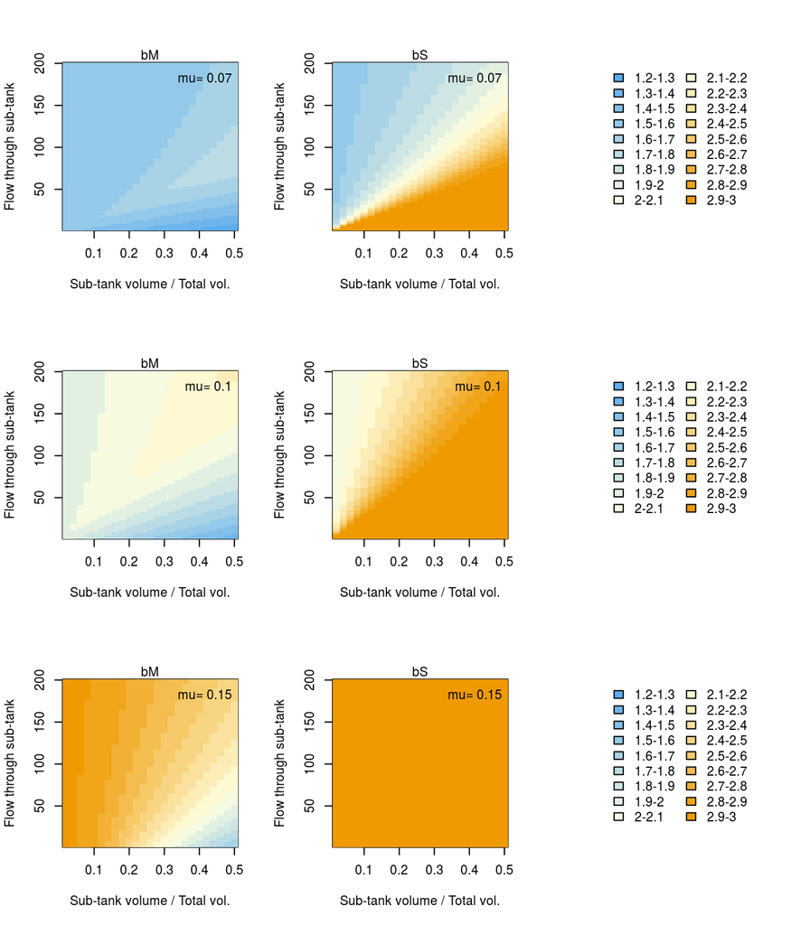

## 6.2 One-dimensional models

### 6.2.1 Diffusion

#### 6.2.1.1 Problem description

This model simulates diffusion into a material driven by a constant known concentration at a boundary (see figure below). The initial concentration of transported substance is zero in the entire model domain. The latter is subdivided into layers of equal thickness (semi-discretization) and the dispersion term for each layer is approximated by a central finite difference.

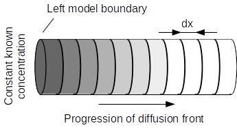

The source code below computes the concentrations in all layers for selected time points by means of numerical integration. The results are visually compared to analytical solutions for the same initial and boundary conditions.

#### 6.2.1.2 Tabular model definition

The model specification is contained directly in the R code below.

#### 6.2.1.3 Implementation of functions

For this model, no functions need to be implemented.

#### 6.2.1.4 R code to run the model

A `rodeo`-based implementation and application of the model is demonstrated by the following R code.

```r
rm(list=ls())

# Adjustable settings ##########################################################
dx <- 0.01                           # spatial discretization (m)
nCells <- 100                        # number of layers (-)
d <- 5e-9                            # diffusion coefficient (m2/s)
cb <- 1                              # boundary concentr. at all times (mol/m3)
times <- c(0,1,6,14,30,89)*86400     # times of interest (seconds)
# End of settings ##############################################################

# Load packages
library("deSolve")
library("rodeo")

# Specification of the model
vars <- data.frame(stringsAsFactors=FALSE,
  name="c", unit="mol/m3", description="concentration")
pars <- data.frame(matrix(c(
    "d",         "m2/s",    "diffusion coefficient",
    "dx",        "m",       "thickness of layers",
    "cb",        "mol/m3",  "boundary concentration",
    "leftmost",  "-",       "0/1 mask to select boundary layer"
  ), ncol=3, byrow=TRUE, dimnames=list(NULL, c("name", "unit", "description"))))
funs <- data.frame(name=character(0), unit=character(0), description=character(0))
# Note: Boundary value is imposed on leftmost cell directly, by omitting
#       diffusion coefficient/length
pros <- data.frame(stringsAsFactors=FALSE,
  name="diff", unit="mol/m3/s", description="diffusion", expression=
  "d/(dx^2) * (left(c) - 2*c + right(c)) + leftmost * (cb - c)")
stoi <- matrix(1, ncol=1, nrow=1, dimnames=list("diff","c"))

# Initialize rodeo object
model <- rodeo$new(vars=vars, pars=pars, funs=funs, pros=pros, stoi=stoi,
  asMatrix=TRUE, dim=(nCells))

# Assign initial values and parameters
model$setVars(cbind(c=rep(0, nCells)))
model$setPars(cbind(d=d, dx=dx,cb=cb,
  leftmost= c(1, rep(0, nCells-1))
))

# Generate code, compile into shared library, load library
lib <- model$compile(NULL)
dyn.load(lib["libFile"])

# Numeric solution
solNum <- ode(y=model$getVars(), times=times, func=lib["libFunc"],
  parms=model$getPars(), dllname=lib["libName"],
  nout=model$lenPros()*prod(model$getDim()),
  jactype="bandint", bandup=1, banddown=1)

# Clean-up
dyn.unload(lib["libFile"])
invisible(file.remove(lib["libFile"]))

# Function providing the analytical solution
erfc <- function(x) { 2 * pnorm(x * sqrt(2), lower=FALSE) }
solAna <- function (x,t,d,cb) { cb * erfc(x / 2 / sqrt(d*t)) }

# Graphically compare numerical and analytical solution
nc <- 2
nr <- ceiling(length(times) / nc)
layout(matrix(1:(nc*nr), ncol=nc, byrow=TRUE))
par(mar=c(4,4,1,1))
for (t in times) {
  plot(c(0,nCells*dx), c(0,cb), type="n", xlab="Station (m)", ylab="mol/m3")
  # Numeric solution (stair steps of cell-average); graph shifted by 1/2 dx
  # because whole 1st layer was set to boundary value
  stations <- seq(from=0, by=dx, length.out=nCells+1)
  concs <- solNum[solNum[,1]==t, paste0("c.",1:nCells)]
  lines(stations-dx/2, c(concs,concs[length(concs)]), type="s", col="steelblue4")
  # Analytical solution (for center of cells)
  stations <- seq(from=dx/2, to=(nCells*dx)-dx/2, by=dx)
  concs <- solAna(x=stations, t=t, d=d, cb=cb)
  lines(stations, concs, col="red", lty=2)
  # Extras
  legend("topright", bty="n", paste("After",t/86400,"days"))
  if (t == times[1]) legend("right",lty=1:2,
    col=c("steelblue4","red"),legend=c("Numeric", "Exact"),bty="n")
  abline(v=0)
}
layout(1)
```

#### 6.2.1.5 Model output

The output from the above code is shown below. The boundary where a constant external concentration was imposed is marked by the vertical line at station 0.

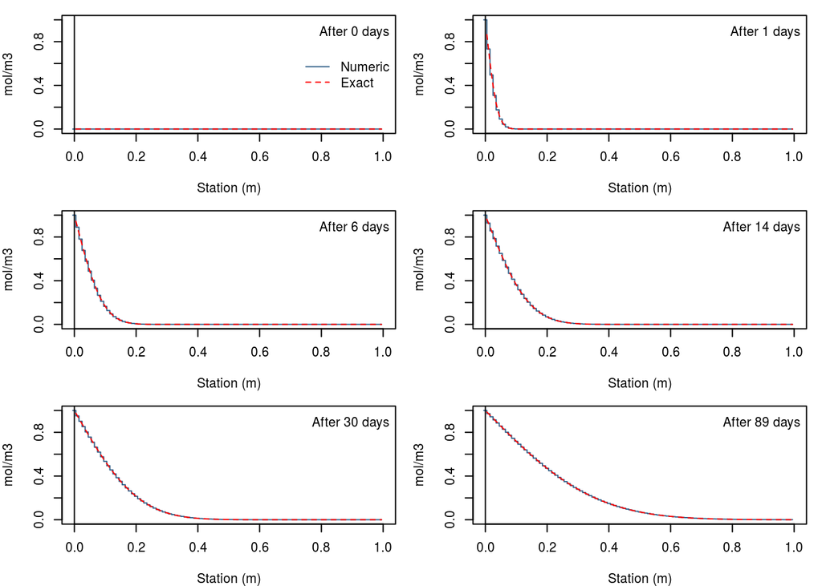

### 6.2.2 Advective-dispersive transport

#### 6.2.2.1 Problem description

The model simulates the transport of a conservative tracer along a river reach assuming steady-uniform flow, i.e. constant flow rate and uniform cross-section (see figure below). The tracer is injected somewhere in the middle of the reach and instantaneous mixing over the cross-section is assumed.

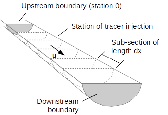

For the advection term, a backward finite difference scheme is used. The dispersion term is approximated by central finite differences. The dispersion coefficient is corrected for the effect of numerical dispersion.

To verify the result of numerical integration, outputs are visually compared to a classic analytical solution of the one-dimensional advection-dispersion equation.

#### 6.2.2.2 Tabular model definition

The model’s state variables, parameters, and functions are declared below, followed by the speficition of process rates and stoichiometric factors.

Declaration of state variables (file ‘vars.txt’).

| name | unit | description |
| --- | --- | --- |
| c | g/m3 | tracer concentration |

Declaration of parameters (file ‘pars.txt’).

| name | unit | description |
| --- | --- | --- |
| u | m/s | advection velocity |
| d | m2/s | dispersion coefficient |
| dx | m | length of sub-section |
| leftmost | none | 0/1 mask to select leftmost sub-section |
| rightmost | none | 0/1 mask to select rightmost sub-section |

Declaration of functions (file ‘funs.txt’).

| name | unit | description |
| --- | --- | --- |
| cUp | mol/m3/s | upstream concentration |
| cDn | mol/m3/s | downstream concentration |

Definition of process rates (file ‘pros.txt’).

| name | unit | description | expression |
| --- | --- | --- | --- |
| adv | mol/m3/s | advection | u/dx * (left(c)-c) |
| advL | mol/m3/s | advection over upstr. boundary | u/dx * (cUp(time)-c) |
| dis | mol/m3/s | dispersion | d/(dx^2) * (left(c) - 2*c + right(c)) |
| disL | mol/m3/s | disp. over upstr. boundary | d/dx * (cUp(time) - c) |
| disR | mol/m3/s | disp. over downstr. boundary | d/dx * (cDn(time) - c) |

Definition of stoichiometric factors (file ‘stoi.txt’).

| process | variable | expression |
| --- | --- | --- |
| adv | c | 1 |
| advL | c | leftmost |
| dis | c | 1 |
| disL | c | leftmost |
| disR | c | rightmost |

#### 6.2.2.3 Implementation of functions

The contents of a file ‘functions.f95’ implementing a Fortran module ‘functions’ is shown below. The module contains all non-intrinsic functions appearing in the process rate expressions or stoichiometric factors.

```
module functions
   implicit none

   double precision, parameter:: ZERO= 0d0

   contains

   function cUp (time) result (r)
     double precision, intent(in):: time
     double precision:: r
     r= ZERO                               ! same as for analytic solution
   end function

   function cDn (time) result (r)
     double precision, intent(in):: time
     double precision:: r
     r= ZERO                               ! same as for analytic solution
   end function

 end module
```

#### 6.2.2.4 R code to run the model

A `rodeo`-based implementation and application of the model is demonstrated by the following R code. It makes use of the tables and function code displayed above.

```r
rm(list=ls())

# Adjustable settings ##########################################################
fileFun <- "functions.f95"
u <- 1                                 # advective velocity (m/s)
d <- 30                                # longit. dispersion coefficient (m2/s)
wetArea <- 50                          # wet cross-section area (m2)
dx <- 10                               # length of a sub-section (m)
nCells <- 1000                         # number of sub-sections
inputCell <- 100                       # index of sub-section with tracer input
inputMass <- 10                        # input mass (g)
times <- c(0,30,60,600,1800,3600)      # times (seconds)
# End of settings ##############################################################

# Load packages
library("deSolve")
library("rodeo")

# Make sure that vector of times starts with zero
times <- sort(unique(c(0, times)))

# Initialize rodeo object
rd <- function(f) {read.table(file=f,
  header=TRUE, sep="\t", stringsAsFactors=FALSE) }
model <- rodeo$new(vars=rd("vars.txt"), pars=rd("pars.txt"),
  funs=rd("funs.txt"), pros=rd("pros.txt"), stoi=rd("stoi.txt"),
  asMatrix=FALSE, dim=c(nCells))

# Numerical dispersion for backward finite-difference approx. of advection term
dNum <- u*dx/2

# Assign initial values and parameters
model$setVars(cbind(
  c=ifelse((1:nCells)==inputCell, inputMass/wetArea/dx, 0)
))
model$setPars(cbind(
  u=u, d=d-dNum, dx=dx,
  leftmost= c(1, rep(0, nCells-1)),
  rightmost= c(rep(0, nCells-1), 1)
))

# Generate code, compile into shared library, load library
lib <- model$compile(fileFun)
dyn.load(lib["libFile"])

# Numeric solution
solNum <- ode(y=model$getVars(), times=times, func=lib["libFunc"],
  parms=model$getPars(), dllname=lib["libName"],
  nout=model$lenPros()*prod(model$getDim()),
  jactype="bandint", bandup=1, banddown=1)

# Clean-up
dyn.unload(lib["libFile"])
invisible(file.remove(lib["libFile"]))

# Function providing the analytical solution
solAna <- function (x,t,mass,area,disp,velo) {
  mass/area/sqrt(4*pi*disp*t) * exp(-((x-velo*t)^2) / (4*disp*t))
}

# Graphically compare numerical and analytical solution
nc <- 2
nr <- ceiling(length(times) / nc)
layout(matrix(1:(nc*nr), ncol=nc, byrow=TRUE))
par(mar=c(4,4,1,1))
for (t in times) {
  plot(c(0,nCells*dx), c(1e-7,inputMass/wetArea/dx), type="n", xlab="Station (m)",
    ylab="g/m3", log="y")
  # Numeric solution (stair steps of cell-average)
  stations <- seq(from=0, by=dx, length.out=nCells+1)
  concs <- solNum[solNum[,1]==t, paste0("c.",1:nCells)]
  lines(stations, c(concs,concs[length(concs)]), type="s", col="steelblue4")
  # Analytical solution (for center of cells)
  stations <- seq(from=dx/2, to=(nCells*dx)-dx/2, by=dx)
  concs <- solAna(x=stations, t=t, mass=inputMass, area=wetArea, disp=d, velo=u)
  stations <- stations + (inputCell*dx) - dx/2
  lines(stations, concs, col="red", lty=2)
  # Extras
  abline(v=(inputCell*dx) - dx/2, lty=3)
  legend("topright", bty="n", paste("After",t,"sec"))
  if (t == times[1]) legend("right",lty=1:2,
    col=c("steelblue4","red"),legend=c("Numeric", "Exact"),bty="n")
}
layout(1)
```

#### 6.2.2.5 Model output

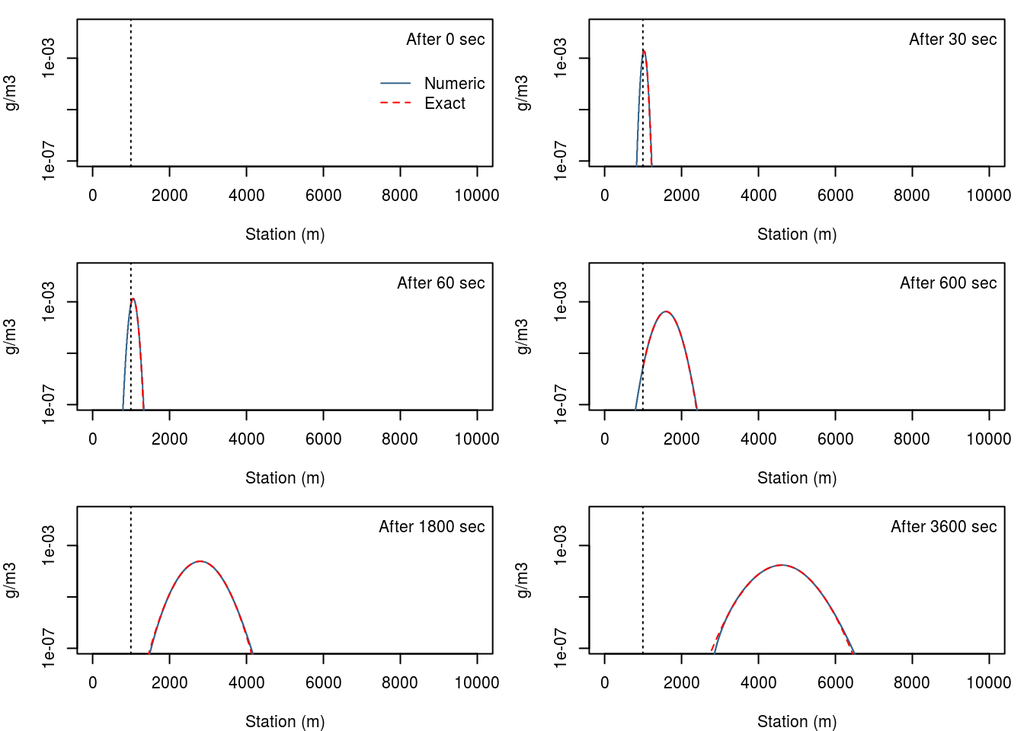

### 6.2.3 Ground water flow

#### 6.2.3.1 Problem description

The model solves the partial differential equation describing one-dimensional (lateral) ground water flow under the [Dupuit-Forchheimer assumption](https://en.wikipedia.org/wiki/Dupuit%E2%80%93Forchheimer_assumption). Flow is simulated along a transect between the watershed boundary and a river (see Figure below).

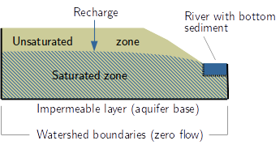

The model has several boundary conditions:

- Zero lateral flow at left margin (boundary of watershed)
- Exchange with river at right margin (leaky aquifer approach, river water level can vary over time)
- No lateral flow accross right boundary (assuming symmetry, i.e. an identical watershed at the other side of the river ).
- Time-variable recharge via percolation through unsaturated zone.

The governing equations can be found in Bronstert et al. (1991). Details on the leakage approach are presented in Rauch (1993), Kinzelbach (1986), as well as Kinzelbach and Rausch (1995).

#### 6.2.3.2 Tabular model definition

The model’s state variables, parameters, and functions are declared below, followed by the speficition of process rates and stoichiometric factors.

Declaration of state variables (file ‘vars.txt’).

| name | unit | description |
| --- | --- | --- |
| h | m | elevation of ground water surface |

Declaration of parameters (file ‘pars.txt’).

| name | unit | description |
| --- | --- | --- |
| dx | m | lateral discretizaton |
| kf | m/day | hydraulic conductivity |
| ne | - | effective porosity |
| h0 | m | elevation of aquifer base |
| hBed | m | river bottom elevation |
| wBed | m | width of river (rectangular x-section) |
| kfBed | m/day | hydraulic conductivity of river bottom layer |
| tBed | m | thickness of river bottom layer |
| leaky | - | 1 for leaky and 0 for normal cells |

Declaration of functions (file ‘funs.txt’).

| name | unit | description |
| --- | --- | --- |
| leak | m/day | exchange flow between river and aquifer |
| hRiv | m | river water surface elevation |
| rch | m/day | recharge rate |

Definition of process rates (file ‘pros.txt’).

| name | unit | description | expression |
| --- | --- | --- | --- |
| flow | m/day | ground water flow | kf * (h-h0) / ne / (dx^2) * (left(h) - 2*h + right(h)) |
| recharge | m/day | recharge | rch(time) / ne |
| leakage | m/day | exch. with river | leaky * leak(h, hRiv(time), hBed, kfBed, tBed, wBed, dx) |

Definition of stoichiometric factors (file ‘stoi.txt’).

| process | variable | expression |
| --- | --- | --- |
| flow | h | 1 |
| recharge | h | 1 |
| leakage | h | 1 |

#### 6.2.3.3 Implementation of functions

The contents of a file ‘functions.f95’ implementing a Fortran module ‘functions’ is shown below. The module contains all non-intrinsic functions appearing in the process rate expressions or stoichiometric factors.

```
! This is file 'functions.f95'
 module functions
   implicit none
   contains

   double precision function leak (hAqui, hRiv, hBed, kfBed, tBed, wBed, dx)
     double precision, intent(in):: hAqui, hRiv, hBed, kfBed, tBed, wBed, dx
     double precision:: wetPerim, leakFact
     wetPerim = wBed + 2 * (hRiv - hBed)       ! rectangular x-section
     leakFact = kfBed / tBed * wetPerim / dx
     if (hAqui > hBed) then
       leak = leakFact * (hRiv - hAqui)
     else
       leak = leakFact * (hRiv - hBed)
     end if
   end function

   double precision function rch (time)
     double precision, intent(in):: time
     rch = 0.2d0 / 365d0                          ! held constant at 200 mm/year
   end function

   double precision function hRiv (time)
     double precision, intent(in):: time
     hRiv = 11                                    ! held constant at 11 m
   end function

 end module
```

#### 6.2.3.4 R code to run the model

A `rodeo`-based implementation and application of the model is demonstrated by the following R code. It makes use of the tables and function code displayed above.

```r
rm(list=ls())

# Adjustable settings ##########################################################
fileFun <- "functions.f95"
dx <- 10                             # spatial discretization (m)
nx <- 100                            # number of boxes (-)
times <- seq(0, 12*365, 30)          # times of interest (days)
# End of settings ##############################################################

# Load packages
library("deSolve")
library("rodeo")

# Initialize model
rd <- function(f) {read.table(file=f,
  header=TRUE, sep="\t", stringsAsFactors=FALSE)}
model <- rodeo$new(vars=rd("vars.txt"), pars=rd("pars.txt"),
  funs=rd("funs.txt"), pros=rd("pros.txt"),
  stoi=rd("stoi.txt"), asMatrix=FALSE, dim=nx)

# Assign initial values and parameters
model$setVars(cbind( h=rep(11, nx) ))
model$setPars(cbind( dx=rep(dx, nx), kf=rep(5., nx), ne=rep(0.17, nx),
  h0=rep(-10, nx), hBed=rep(10, nx), wBed=rep(0.5*dx, nx), kfBed=rep(5., nx),
  tBed=rep(0.1, nx), leaky=c(1, rep(0, nx-1)) ))

# Generate code, compile into shared library, load library
lib <- model$compile(fileFun)
dyn.load(lib["libFile"])

# Integrate
out <- deSolve::ode(y=model$getVars(), times=times, func=lib["libFunc"],
  parms=model$getPars(), dllname=lib["libName"],
  nout=model$lenPros()*prod(model$getDim()),
  jactype="bandint", bandup=1, banddown=1)

# Clean-up
dyn.unload(lib["libFile"])
invisible(file.remove(lib["libFile"]))

# Plot results
filled.contour(x=out[,"time"]/365.25, y=(1:nx)*dx-dx/2,
  z=out[,names(model$getVars())], xlab="Years", ylab="Distance to river (m)",
  color.palette=colorRampPalette(c("steelblue2","lightyellow","darkorange")),
  key.title= mtext(side=3, "Ground water surf. (m)", padj=-0.5))
```

#### 6.2.3.5 Model output

The output of the above code is shown below. Starting from a flat ground water surface (left margin) the system runs into a steady state after a couple of years. The steady state ground water surface reflects the equilibrium between recharge and exfiltration to the river governed by the aquifer’s transmissivity as well as the conductivity of the river bed.

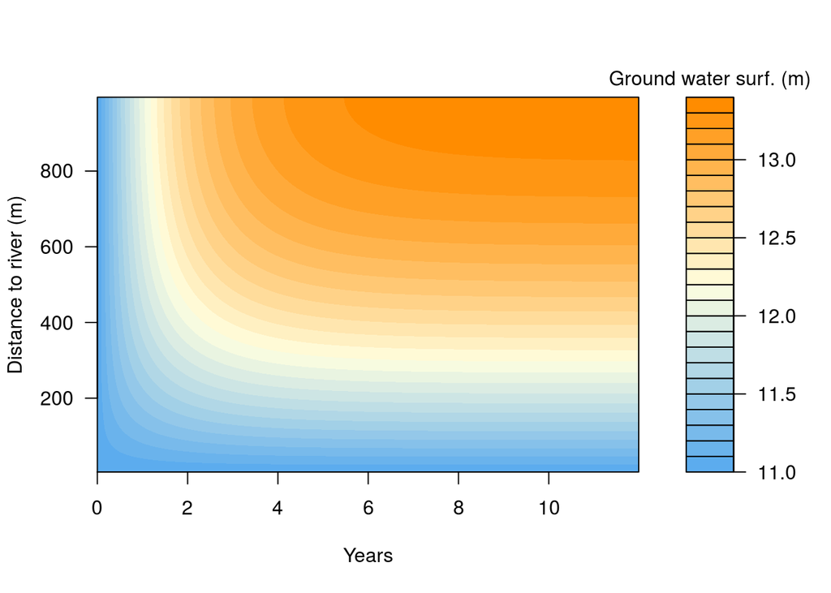

### 6.2.4 Antibiotic resistant bacteria in a river

#### 6.2.4.1 Problem description

This section demonstrates the *re-implementation* of an existing model originally published by Hellweger, Ruan, and Sanchez (2011). It considers the fate of E. coli bacteria in a stream loaded with the antibiotic Tetracycline. The model covers both the (moving) water column and the (fixed) bottom sediments. In contrast to the original implementation of Hellweger, Ruan, and Sanchez (2011), the tanks-in-series concept (see Figure below) was adopted to simulate longitudinal transport in the water column. The key idea of this concept is to represent a river reach by a cascade of fully-mixed tanks whose number ($n$) is adjusted to mimic the relative magnitude of advection and longitudinal dispersion. This is expressed by the relation $n = \frac{Pe}{2}+1$ where $Pe$ is the dimensionless Peclet number. The latter is related to the cross-section average velocity $u_L$, the reach length $L$, and the longitudinal dispersion coefficient $D_L$ according to $Pe = \frac{u_L \cdot L}{D_L}$ (Elgeti 1996).

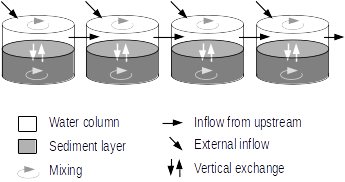

The tanks-in-series concept comes with two constraints: First, it is inefficient when applied to systems with negligible dispersion (consider the case $D_L \rightarrow 0$ in the just mentioned relation). Second, depending on the solver, the Courant criterion must be obeyed when chosing the maximum integration time step $\Delta t$ which should be $\Delta t \le \frac{L}{n \cdot u_L}$. Note that the term $L/{u_L}$ can be expanded with the cross-section area to yield the quotient of storage volume and flow rate, being the usual definition of a mixed tank’s residence time.

#### 6.2.4.2 Tabular model definition

The model’s state variables comprise the concentrations of 12 components listed in the table below. Each component in the water column (suffix `_w`) has its counterpart in the sediment (suffix `_s`). With regard to bacteria, two strains of E. coli are distinguished: a Tetracycline resistant strain and a susceptible one.

Declaration of state variables (file ‘vars.txt’).

| name | unit | description | initial |
| --- | --- | --- | --- |
| S_w | g C/m3 | susceptible bacteria in water | 0.180 |
| S_s | g C/m3 | susceptible bacteria in sediment | 1.800 |
| R_w | g C/m3 | resistant bacteria in water | 0.020 |
| R_s | g C/m3 | resistant bacteria in sediment | 8.000 |
| POM_w | g C/m3 | particulate OM in water | 10.000 |
| POM_s | g C/m3 | particulate OM in sediment | 75.000 |
| TSS_w | g DW/m3 | total suspended solids in water | 16.000 |
| TSS_s | g DW/m3 | total suspended solids in sediment | 160.000 |
| A_w | g/m3 | total antibiotic concentration in water | 0.002 |
| A_s | g/m3 | total antibiotic concentration in sediment | 0.020 |
| DOM_w | g C/m3 | dissolved OM in water | 3.200 |
| DOM_s | g C/m3 | dissolved OM in sediment | 32.000 |

The values displayed in the rightmost column of the above table are used as initial values in the model application. Concentrations are generally specified as mass per bulk volume in units of mg/L. The mass of total suspended solids is quantified as dry weight; masses of biogenic organic matter, including bacteria, are expressed on a Carbon basis. For E. coli, biomass can be converted into cell numbers using a factor of roughly $1 \cdot 10^{-13}$ g Carbon / cell.

This conversion is based on information from the [bionumbers data base](http://bionumbers.hms.harvard.edu/bionumber.aspx?&id=103010) reporting a value of 7e+9 Carbon atoms per E. coli cell. Taking into account the Avogadro constant (about 6e23 atoms/mol) and the molar mass of Carbon (12 g/mol), one obtains 7e+9 / 6e23 * 12 = 1.4e-13 g Carbon / cell. An alternative estimate (Hellweger, Ruan, and Sanchez (2011), supplement page S12) is based on dry weight of E. coli (180e-15 g/cell) and an approximate ratio of 0.5 g Carbon /g dry weight. The corresponding estimate is 180e-15 * 0.5 = 0.9e-13 g Carbon / cell.

The state variables’ dynamics are controlled by a variety of processes specified in tabular form below.

Definition of process rates (file ‘pros.txt’).

| name | unit | description | expression |
| --- | --- | --- | --- |
| decay_w | g A/m3/d | decay of antibiotic in water | ka_w * A_w |
| decay_s | g A/m3/d | decay of antibiotic in sediment | ka_s * A_s |
| hydrolysis_w | g C /m3/d | POM hydrolysis in water | kh_w * POM_w |
| hydrolysis_s | g C /m3/d | POM hydrolysis in sediment | kh_s * POM_s |
| production | g C/m3/d | POM production | P / dw |
| settl_S | g C/m2/d | settling of susceptible bacteria | us * fp * S_w |
| settl_R | g C/m2/d | settling of resistant bacteria | us * fp * R_w |
| settl_A | g C/m2/d | settling of antibiotic | us * A_part(A_w, kd_DOM, kd_TSS, DOM_w, TSS_w) |
| settl_POM | g C/m2/d | settling of particulate OM | us * POM_w |
| settl_TSS | g DW/m2/d | settling of suspended solids | us * TSS_w |
| resusp_S | g C/m2/d | resuspension of susceptible bacteria | ur * S_s |
| resusp_R | g C/m2/d | resuspension of resistant bacteria | ur * R_s |
| resusp_A | g C/m2/d | resuspension of antibiotic | ur * A_part(A_s, kd_DOM, kd_TSS, DOM_s, TSS_s) |
| resusp_POM | g C/m2/d | resuspension of particulate OM | ur * POM_s |
| resusp_TSS | g DW/m2/d | resuspension of suspended solids | ur * TSS_s |
| diffusion_A | g C/m2/d | diff. sed.-water flux of antibiotic | ud * (A_diss(A_w, kd_DOM, kd_TSS, DOM_w, TSS_w) - por * A_diss(A_s, kd_DOM, kd_TSS, DOM_s, TSS_s)) |
| diffusion_DOM | g C/m2/d | diff. sed.-water flux of dissolved OM | ud * (DOM_w - por * DOM_s) |
| growth_S_w | g C/m3/d | growth of susceptible bacs in water | kg * S_w * DOM_w / (DOM_w + h_DOM) * max(0, 1 - A_free(A_w, kd_DOM, kd_TSS, DOM_w, TSS_w) / Amic) |
| growth_S_s | g C/m3/d | growth of susceptible bacs in sediment | kg * S_s * DOM_s / (DOM_s + h_DOM) * max(0, 1 - A_free(A_s, kd_DOM, kd_TSS, DOM_s, TSS_s) / Amic) |
| growth_R_w | g C/m3/d | growth of resistant bacs in water | kg * R_w * DOM_w / (DOM_w + h_DOM) * (1 - alpha) |
| growth_R_s | g C/m3/d | growth of resistant bacs in sediment | kg * R_s * DOM_s / (DOM_s + h_DOM) * (1 - alpha) |
| respiration | 1/d | respiration of bacteria | kr |
| segregation_w | g C/m3/d | segregational loss in water | ks * R_w |
| segregation_s | g C/m3/d | segregational loss in sediment | ks * R_s |
| conjugation_w | g C/m3/d | conjugation in water | kc * S_w * R_w |
| conjugation_s | g C/m3/d | conjugation in sediment | kc * S_s * R_s |
| transport_S | g C/m3/d | transport of susceptible bacteria | 1 / V * (Q_in * (S_in - S_w) + Q * (left(S_w) - S_w)) |
| transport_R | g C/m3/d | transport of resistant bacteria | 1 / V * (Q_in * (R_in - R_w) + Q * (left(R_w) - R_w)) |
| transport_A | g C/m3/d | transport of antibiotic | 1 / V * (Q_in * (A_in - A_w) + Q * (left(A_w) - A_w)) |
| transport_DOM | g C/m3/d | transport of dissolved OM | 1 / V * (Q_in * (DOM_in - DOM_w) + Q * (left(DOM_w) - DOM_w)) |
| transport_POM | g C/m3/d | transport of particulate OM | 1 / V * (Q_in * (POM_in - POM_w) + Q * (left(POM_w) - POM_w)) |
| transport_TSS | g DW/m3/d | transport of suspended solids | 1 / V * (Q_in * (TSS_in - TSS_w) + Q * (left(TSS_w) - TSS_w)) |

Besides the physical phenomena of advection and dispersion, the list of processes includes growth and respiration losses of bacteria, as well as gene transfer between the two strains of E. coli. Particularly, the model describes the horizontal transfer of Tetracycline resistance through the exchange of plasmids (conjugation) as well as the potential loss of the plasmid during cell division (segregational loss). While carriage of the resistance genes is clearly advantageous under exposure to the antibiotic, the synthesis of plasmids also has side effects to the cell, e. g. in the form of physiological costs. This phenomenon is described as a reduction of the growth rate of the Tetracycline-resistant E. coli strain but evolutionary reduction of plasmid costs (Lenski 1998) is neglected.

Tetracycline undergoes photolytic decay (Wammer et al. 2011) which is modeled as a first-order process. The antibiotic is also known to bind to organic and inorganic matter in relevant percentages (Tolls 2001). Hence, sorption effects must be included in the model to obtain realistic estimates of the freely available Tetracycline concentration to which the bacteriostatic effect is attributed (Chen et al. 2015). As in many bio-geo-chemical codes, it is assumed that sorption equilibria arise instantaneously. As this leads to a set of algebraic equations rather than ODE, sorption is not explicitly listed in the above table of processes.

The stoichiometric factors linking the processes with the state variables’ derivatives are provided in matrix format below.

Stoichiometric factors (file ‘stoi.txt’).

| process | S_w | S_s | R_w | R_s | POM_w | POM_s | TSS_w | TSS_s | A_w | A_s | DOM_w | DOM_s |
| --- | --- | --- | --- | --- | --- | --- | --- | --- | --- | --- | --- | --- |
| decay_w |  |  |  |  |  |  |  |  | -1 |  |  |  |
| decay_s |  |  |  |  |  |  |  |  |  | -1 |  |  |
| settl_S | -1/dw | 1/ds |  |  |  |  |  |  |  |  |  |  |
| settl_R |  |  | -1/dw | 1/ds |  |  |  |  |  |  |  |  |
| settl_POM |  |  |  |  | -1/dw | 1/ds |  |  |  |  |  |  |
| settl_TSS |  |  |  |  |  |  | -1/dw | 1/ds |  |  |  |  |
| settl_A |  |  |  |  |  |  |  |  | -1/dw | 1/ds |  |  |
| resusp_S | 1/dw | -1/ds |  |  |  |  |  |  |  |  |  |  |
| resusp_R |  |  | 1/dw | -1/ds |  |  |  |  |  |  |  |  |
| resusp_POM |  |  |  |  | 1/dw | -1/ds |  |  |  |  |  |  |
| resusp_TSS |  |  |  |  |  |  | 1/dw | -1/ds |  |  |  |  |
| resusp_A |  |  |  |  |  |  |  |  | 1/dw | -1/ds |  |  |
| diffusion_A |  |  |  |  |  |  |  |  | -1/dw | 1/ds |  |  |
| diffusion_DOM |  |  |  |  |  |  |  |  |  |  | -1/dw | 1/ds |
| hydrolysis_w |  |  |  |  | -1 |  |  |  |  |  | 1 |  |
| hydrolysis_s |  |  |  |  |  | -1 |  |  |  |  |  | 1 |
| production |  |  |  |  | 1 |  |  |  |  |  |  |  |
| growth_S_w | 1 |  |  |  |  |  |  |  |  |  | -1/Y |  |
| growth_S_s |  | 1 |  |  |  |  |  |  |  |  |  | -1/Y |
| growth_R_w |  |  | 1 |  |  |  |  |  |  |  | -1/Y |  |
| growth_R_s |  |  |  | 1 |  |  |  |  |  |  |  | -1/Y |
| respiration | -S_w | -S_s | -R_w | -R_s |  |  |  |  |  |  |  |  |
| segregation_w | 1 |  | -1 |  |  |  |  |  |  |  |  |  |
| segregation_s |  | 1 |  | -1 |  |  |  |  |  |  |  |  |
| conjugation_w | -1 |  | 1 |  |  |  |  |  |  |  |  |  |
| conjugation_s |  | -1 |  | 1 |  |  |  |  |  |  |  |  |
| transport_S | 1 |  |  |  |  |  |  |  |  |  |  |  |
| transport_R |  |  | 1 |  |  |  |  |  |  |  |  |  |
| transport_POM |  |  |  |  | 1 |  |  |  |  |  |  |  |
| transport_TSS |  |  |  |  |  |  | 1 |  |  |  |  |  |
| transport_A |  |  |  |  |  |  |  |  | 1 |  |  |  |
| transport_DOM |  |  |  |  |  |  |  |  |  |  | 1 |  |

The model specification is completed by the declaration of parameters and functions that appear in the process rate expressions (Tables below). Table numbers appearing in column ‘references’ refer to the supplement of the Hellweger, Ruan, and Sanchez (2011) paper.

Declaration of parameters (file ‘pars.txt’).

| name | unit | description | default | references |
| --- | --- | --- | --- | --- |
| dw | m | depth of water column | 6.0e-01 | guess |
| ds | m | depth of sediment layer | 3.0e-02 | guess |
| por | - | porosity of sediments | 3.0e-01 | guess |
| ka_w | 1/d | rate constant of antibiotic decay in water | 1.0e-01 | Table S4 |
| ka_s | 1/d | rate constant of antibiotic decay in sediments | 0.0e+00 | Table S4 |
| kd_DOM | m3/g C | coefficient for antibiotic sorption to DOM | 1.6e-02 | Table S4 |
| kd_TSS | m3/g DW | coefficient for antibiotic sorption to TSS | 2.0e-04 | Table S4 |
| us | m/d | settling velocity | NA | Table S6 |
| ur | m/d | resuspension velocity | NA | Table S6 |
| ud | m/d | velocity describing turbulent diffusion | 5.0e-03 | Table S6 |
| P | g C/m2/d | rate of POM production | 2.3e+00 | Table S6 |
| kh_w | 1/d | rate constant of POM hydrolysis in water | 5.0e-02 | Table S6 |
| kh_s | 1/d | rate constant of POM hydrolysis in sediments | 5.0e-02 | Table S6 |
| fp | - | fraction of water-column bacteria being bound to particles | 1.0e-01 | Table S6 |
| kr | 1/d | bacteria respiration rate constant | 1.1e-01 | Table S4 |
| kg | 1/d | max. growth rate of sensitive bacteria | 2.6e+00 | Table S4 |
| h_DOM | g C/m3 | half saturation concentration of DOM for bacteria growth | 9.1e+00 | Table S6 |
| Y | - | yield; bacterial carbon / DOM carbon | 3.6e-01 | Table S7 |
| Amic | g A/m3 | minimum inhibiting conc. of freely dissolved antibiotic | 1.3e-02 | Table S6 |
| ks | 1/d | rate constant of segregational loss | 4.0e-02 | Table S6 |
| kc | m3/g C/d | constant to control conjugation | 1.0e-05 | Table S6 |
| alpha | - | reduction of growth rate due to resistance (plasmid cost) | 1.0e-01 | Table S6 |
| S_in | g C/m3 | concentrations in inflow | 1.8e-02 | Table S7 |
| R_in | g C/m3 | concentrations in inflow | 2.0e-03 | Table S7 |
| A_in | g C/m3 | concentrations in inflow | 2.0e-03 | guess |
| DOM_in | g C/m3 | concentrations in inflow | 3.2e+00 | Table S7 |
| POM_in | g C/m3 | concentrations in inflow | 4.0e-01 | Table S7 |
| TSS_in | g TSS/m3 | concentrations in inflow | 1.6e+01 | Table S6 |
| V | m3 | reactor volume | NA | - |
| Q_in | m3/d | external inflow (not from upstream reactor) | NA | - |
| Q | m3/d | inflow from upstream reactor | NA | - |

Declaration of functions (file ‘funs.txt’).

| name | unit | description |
| --- | --- | --- |
| A_part | mol/m3 | concentration of antibiotic; particulate fraction |
| A_diss | mol/m3 | concentration of antibiotic; freely dissolved and sorbed to dissolved matter |
| A_free | mol/m3 | concentration of antibiotic; freely dissolved |
| max | - | maximum of arguments |

#### 6.2.4.3 Implementation of functions

For computational efficiency, the source code is generated in Fortran, hence, the functions need to be implemented in Fortran as well (source code shown below). They return the different fractions of the antibiotic (particulate, dissolved, and freely dissolved) in the presence of two sorbents (DOM, TSS) assuming linear sorption isothermes. The underlying equations can be found in the supplement of Hellweger, Ruan, and Sanchez (2011), number S2-S4.

```
module functions
   implicit none
   contains

   ! Consult the functions' declaration table to see what these functions do

   double precision function A_part(A_tot, kd_DOM, kd_TSS, DOM, TSS) result (r)
     double precision, intent(in):: A_tot, kd_DOM, kd_TSS, DOM, TSS
     r= A_tot * kd_TSS * TSS / (1d0 + kd_DOM * DOM + kd_TSS * TSS)
   end function

   double precision function A_diss(A_tot, kd_DOM, kd_TSS, DOM, TSS) result (r)
     double precision, intent(in):: A_tot, kd_DOM, kd_TSS, DOM, TSS
     r= A_tot - A_part(A_tot, kd_DOM, kd_TSS, DOM, TSS)
   end function

   double precision function A_free(A_tot, kd_DOM, kd_TSS, DOM, TSS) result (r)
     double precision, intent(in):: A_tot, kd_DOM, kd_TSS, DOM, TSS
     r= A_tot / (1d0 + kd_DOM * DOM + kd_TSS * TSS)
   end function

 end module
```

#### 6.2.4.4 R code with corresponding graphical outputs

The following code section instantiates a `rodeo` object using the tabular data from above and it produces the required Fortran library. Note that basic properties of the simulated system, namely the number of tanks, are defined at the top of the listing.

After object creation and code generation, the state variables are initialized using the numbers from the table displayed above (column ‘initial’). Likewise, the values of parameters are taken column ‘default’ of the respective table. Note that some parameters are set to `NA`, i.e. they are initially undefined. Those values are either computed from the system’s physical properties or from mass balance considerations according to supplement S 3.3.c of Hellweger, Ruan, and Sanchez (2011).

```r
# Adjustable settings ##########################################################

# Properties of the reach not being parameters of the core model
len <-   125000             # reach length (m)
uL  <- 0.5 * 86400          # flow velocity (m/d)
dL  <- 300 * 86400          # longitudinal dispersion coefficient (m2/d)
xsArea <- 0.6 * 15          # wet cross-section area (m2)

# End of settings ##############################################################

# Computational parameters
nTanks <- trunc(uL * len / dL / 2) + 1 # number of tanks; see Elgeti (1996)
dt_max <- 0.5 * len / nTanks / uL      # max. time step (d); Courant criterion

# Load packages
library("rodeo")
library("deSolve")
library("rootSolve")

# Initialize rodeo object
rd <- function(f, ...) { read.table(file=f, header=TRUE, sep="\t", ...) }
model <- rodeo$new(vars=rd("vars.txt"), pars=rd("pars.txt"), funs=rd("funs.txt"),
  pros=rd("pros.txt"), stoi=as.matrix(rd("stoi.txt", row.names="process")),
  asMatrix=TRUE, dim=c(nTanks))

# Generate code, compile into shared library, load library
lib <- model$compile(sources="functions.f95")
dyn.load(lib["libFile"])

# Assign initial values
vars <- matrix(rep(as.numeric(model$getVarsTable()$initial), each=nTanks),
  ncol=model$lenVars(), nrow=nTanks, dimnames=list(NULL, model$namesVars()))
model$setVars(vars)

# Assign / update values of parameters; River flow is assumed to be steady
# and uniform (i.e. constant in space and time); Settling and resuspension
# velocities are computed from steady-state mass balance as in Hellweger (2011)
pars <- matrix(
  rep(suppressWarnings(as.numeric(model$getParsTable()$default)), each=nTanks),
  ncol=model$lenPars(), nrow=nTanks, dimnames=list(NULL, model$namesPars()))
pars[,"V"] <- xsArea * len/nTanks                           # tank volumes
pars[,"Q"] <- c(0, rep(uL * xsArea, nTanks-1))              # inflow from upstr.
pars[,"Q_in"] <- c(uL * xsArea, rep(0, nTanks-1))           # inflow to tank 1
pars[,"us"] <- pars[,"kh_s"] * pars[,"ds"] /                # settling velocity
  ((vars[,"POM_w"] / vars[,"POM_s"]) -
  (vars[,"TSS_w"] / vars[,"TSS_s"]))
pars[,"ur"] <- pars[,"us"] * vars[,"TSS_w"] /               # resuspension velo.
  vars[,"TSS_s"]
model$setPars(pars)
```

The following code section creates a graphical representation of the stochiometry matrix. Positive (negative) stoichiometric factors are indicated by upward (downward) oriented triangles. The stoichiometric factors for transport processes are displayed as circles since their sign is generally variable as it depends on spatial gradients.

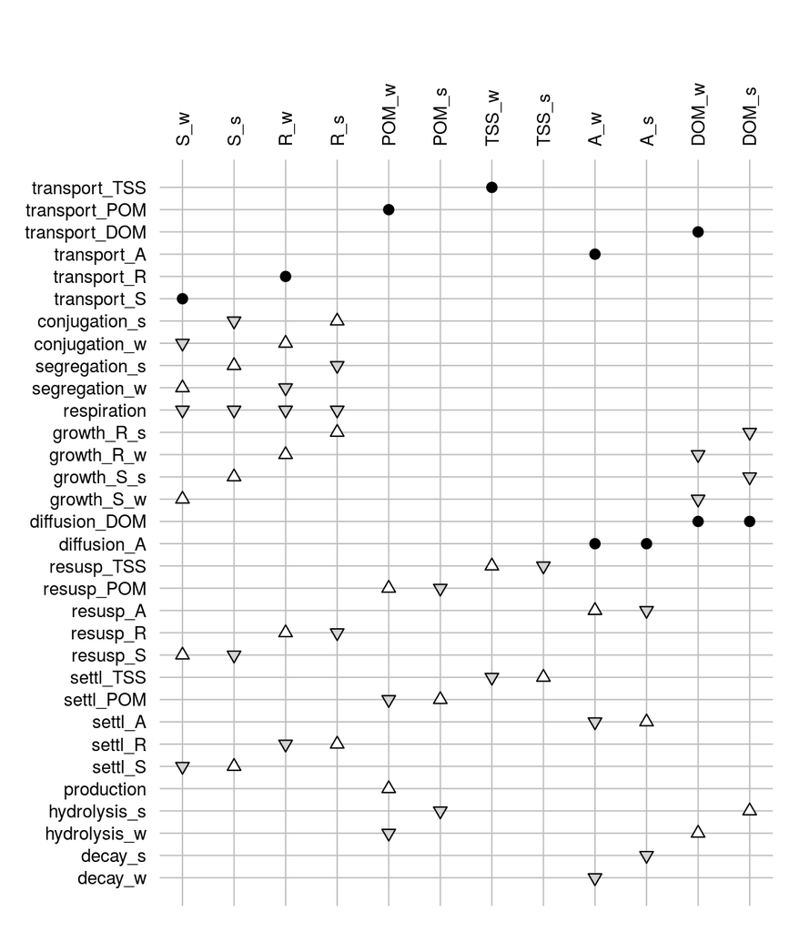

```r
# Plot stoichiometry matrix using symbols
m <- model$stoichiometry(box=1)
clr <- function(x, ignoreSign=FALSE) {
  res <- rep("transparent", length(x))
  if (ignoreSign) {
    res[x != 0] <- "black"
  } else {
    res[x < 0] <- "lightgrey"
    res[x > 0] <- "white"
  }
  return(res)
}
sym <- function(x, ignoreSign=FALSE) {
  res <- rep(NA, length(x))
  if (ignoreSign) {
    res[x != 0] <- 21
  } else {
    res[x < 0] <- 25
    res[x > 0] <- 24
  }
  return(res)
}
omar <- par("mar")
par(mar=c(1,6,6,1))
plot(c(1,ncol(m)), c(1,nrow(m)), bty="n", type="n", xaxt="n", yaxt="n",
  xlab="", ylab="")
abline(h=1:nrow(m), v=1:ncol(m), col="grey")
for (ir in 1:nrow(m)) {
  ignoreSign <- grepl(pattern="^transport.*", x=rownames(m)[ir]) ||
    grepl(pattern="^diffusion.*", x=rownames(m)[ir])
  points(1:ncol(m), rep(ir,ncol(m)), pch=sym(m[ir,1:ncol(m)], ignoreSign),
    bg=clr(m[ir,1:ncol(m)], ignoreSign))
}
mtext(side=2, at=1:nrow(m), rownames(m), las=2, line=0.5, cex=0.8)
mtext(side=3, at=1:ncol(m), colnames(m), las=2, line=0.5, cex=0.8)
par(mar=omar)
rm(m)
```

The next code section demonstrates how a steady-state solution can be obtained by a call to method `steady.1D` from package [`rootSolve`](http://cran.r-project.org/package=rootSolve). This specific solver accounts for the banded structure of the Jacobian matrix resulting from the tanks-in-series approach taking into account the layout of the vector of state variables (explained in the section on multi-box models). Plotting was restricted to the bacteria concentrations in the water column and sediment, respectively.

```r
# Estimate steady-state
std <- rootSolve::steady.1D(y=model$getVars(), time=NULL, func=lib["libFunc"],
  parms=model$getPars(), nspec=model$lenVars(), dimens=nTanks, positive=TRUE,
  dllname=lib["libName"], nout=model$lenPros()*nTanks)
if (!attr(std, which="steady", exact=TRUE))
  stop("Steady-state run failed.")
names(std$y) <- names(model$getVars())

# Plot bacterial densities
stations= ((1:nTanks) * len/nTanks - len/nTanks/2) / 1000     # stations (km)
domains= c(Water="_w", Sediment="_s")                         # domain suffixes
layout(matrix(1:length(domains), ncol=length(domains)))
for (i in 1:length(domains)) {
  R= match(paste0("R",domains[i],".",1:nTanks), names(std$y)) # resistant bac.
  S= match(paste0("S",domains[i],".",1:nTanks), names(std$y)) # susceptibles
  plot(x=range(stations), y=range(std$y[c(S,R)]), type="n",
    xlab=ifelse(i==1,"Station (km)",""), ylab=ifelse(i==1,"mg/l",""))
  lines(stations, std$y[R], lty=1)
  lines(stations, std$y[S], lty=2)
  if (i==1) legend("topleft", bty="n", lty=1:2, legend=c("Resistant","Suscept."))
  mtext(side=3, names(domains)[i])
}
```

The above code outputs the steady-state longitudinal profiles of E. Coli displayed below. The graphs indicate elevated concentrations in the sediment as compared to the water column. Predominance of the resistant strain in sediments is explained by increased antibiotic levels in the dark. Growth conditions for the susceptible strain improve along the flow path due to photolysis of Tetracycline in the water column and subsequent dilution of pore water concentrations.

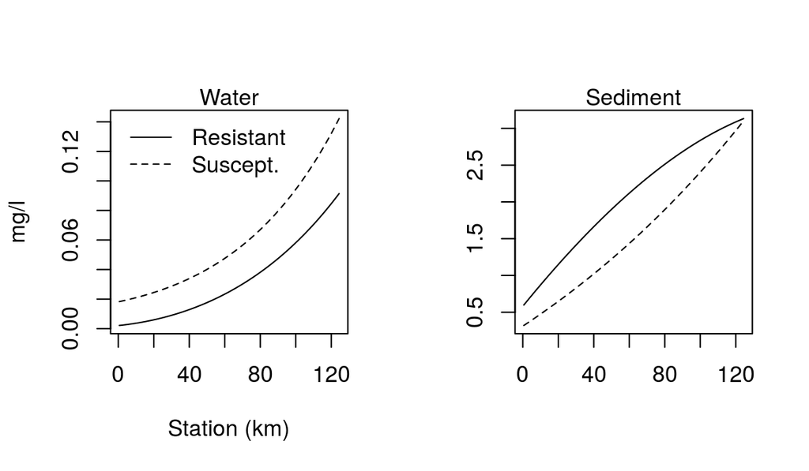

In the next code section, a dynamic solution is obtained using the default integration method from [`deSolve`](http://cran.r-project.org/package=deSolve). As in the steady-state computation above, the solver is informed on the structure of the Jacobian to speed up numerical integration.

Graphical output is generated for a single state variable only, displayed right after the code listing. The plot just illustrates how the computed concentration of susceptibe bacteria in the water column (state variable `S_w`) drifts away from the guessed initial state.

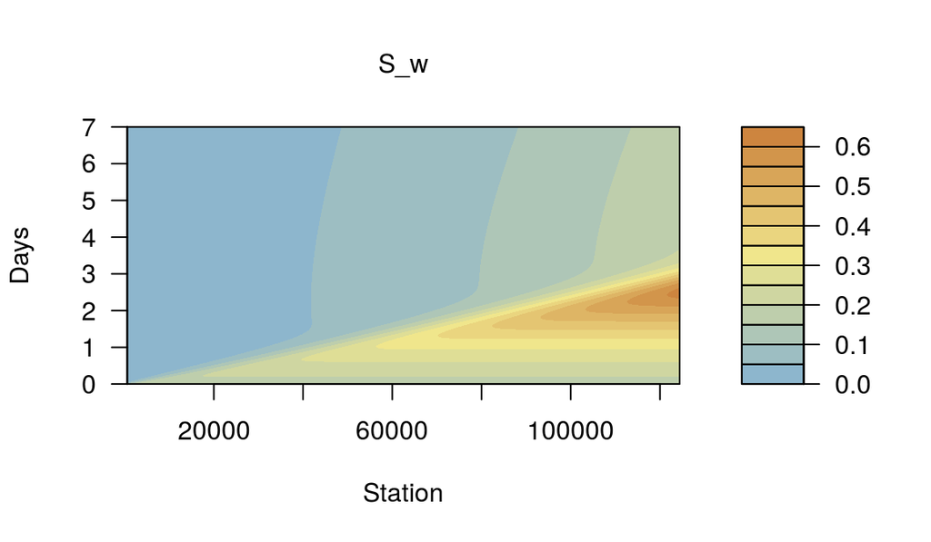

```r
# Dynamic simulation
times <- seq(0, 7, 1/48)                              # requested output times
dyn <- deSolve::ode(y=model$getVars(), times=times, func=lib["libFunc"],
  parms=model$getPars(), NLVL=nTanks, dllname=lib["libName"],
  hmax=dt_max, nout=model$lenPros()*nTanks,
  jactype="bandint", bandup=1, banddown=1)
if (attr(dyn, which="istate", exact=TRUE)[1] != 2)
  stop("Dynamic run failed.")

# Plot dynamic solution
stations= (1:nTanks) * len/nTanks - len/nTanks/2
name <- "S_w"
m <- dyn[ ,match(paste0(name,".",1:nTanks), colnames(dyn))]
filled.contour(x=stations, y=dyn[,"time"], z=t(m), xlab="Station", ylab="Days",
  color.palette=colorRampPalette(c("lightskyblue3","khaki","peru")),
  main=name, cex.main=1, font.main=1)
```

The code below performs a global sensitivity analysis to test the impact of parameter values on a specific quantity of interest, namely the proportion of resistant bacteria after passage of the reach. The four selected parameters were:

1. the constant to control gene transfer by conjugation, `kc`,
2. the rate constant of segregational loss, `ks`,
3. the plasmid costs, `alpha`,
4. the upstream concentration of Tetracycline, `A_in`.

```r
# Define parameter values for sensitivity analysis
testList <- list(
  A_in= c(0.002, 0.005),                              #   input of antibiotic
  alpha= c(0, 0.25),                                  #   cost of resistance
  ks= seq(0, 0.02, 0.002),                            #   loss of resistance
  kc= 10^seq(from=-4, to=-2, by=0.5))                 #   transfer of resistance

# Set up parameter sets
testSets <- expand.grid(testList)

# Function to return the steady-state solution for specific parameters
f <- function(set, y0) {
  p <- model$getPars(asArray=TRUE)
  p[,names(set)] <- rep(as.numeric(set), each=nTanks) # update parameters
  out <- rootSolve::steady.1D(y=y0, time=NULL, func=lib["libFunc"],
    parms=p, nspec=model$lenVars(), dimens=nTanks, positive=TRUE,
    dllname=lib["libName"], nout=model$lenPros()*nTanks)
  if (attr(out, which="steady", exact=TRUE)) {        # solution found?
    names(out$y) <- names(model$getVars())
    down_S_w <- out$y[paste0("S_w",".",nTanks)]       # bacteria concentrations
    down_R_w <- out$y[paste0("R_w",".",nTanks)]       #   at lower end of reach
    return(unname(down_R_w / (down_R_w + down_S_w)))  # fraction of resistant b.
  } else {
    return(NA)                                        # if solver failed
  }
}

# Use already computed steady state solution as initial guess
y0 <- array(std$y, dim=c(nTanks, model$lenVars()),
  dimnames=list(NULL, model$namesVars()))

# Apply model to all sets and store results as 4-dimensional array
res <- array(apply(X=testSets, MARGIN=1, FUN=f, y0=y0),
  dim=lapply(testList, length), dimnames=testList)

# Plot results of the analysis
omar <- par("mar")
par(mar=c(4,4,1.5,1))
breaks <- pretty(res, 8)
colors <- colorRampPalette(c("steelblue2","khaki2","brown"))(length(breaks)-1)
nr <- length(testList$A_in)
nc <- length(testList$alpha)
layout(cbind(matrix(1:(nr*nc), nrow=nr), rep(nr*nc+1, nr)))
for (alpha in testList$alpha) {
  for (A_in in testList$A_in) {
    labs <- (A_in == tail(testList$A_in, n=1)) && (alpha == testList$alpha[1])
    image(x=log10(as.numeric(dimnames(res)$kc)), y=as.numeric(dimnames(res)$ks),
      z=t(res[as.character(A_in), as.character(alpha),,]),
      zlim=range(res), breaks=breaks, col=colors,
      xlab=ifelse(labs, "log10(kc)", ""), ylab=ifelse(labs, "ks", ""))
    if (A_in == testList$A_in[1])
      mtext(side=3, paste0("alpha = ",alpha), cex=par("cex"), line=.2)
    if (alpha == tail(testList$alpha, n=1))
      mtext(side=4, paste0("A_in = ",A_in), cex=par("cex"), las=3, line=.2)
  }
}
plot.new()
legend("left", bty="n", title="% resistant", fill=colors,
  legend=paste0(breaks[-length(breaks)]*100," - ", breaks[-1]*100))
layout(1)
par(mar=omar)

# Clean-up
dyn.unload(lib["libFile"])
invisible(file.remove(lib["libFile"]))
```

Thanks to the Fortran-based model implementation, a reasonable section of the parameter space can be explored within acceptable times. On a recent machine (3 GHz CPU, 8 GB memory) a single steady-state run takes less than 50 ms. This opens up the possibility for more demanding analysis like, for example, Bayesian parameter estimation or more exhaustive sensitivity analyses.

The graphics created by the above listing (see below) illustrate the effect of the four varied parameters on the model output. The analyzed output variable is the percentage of suspended E. coli at the downstream end of the reach being resistant to Tetracycline. The sensitivity with respect to the rate constants of conjugation (`kc`, x-axis) and segregational loss (`ks`, y-axis) is displayed in the individual plots. The input concentration of Tetracycline (`A_in`) increases from the top to the bottom panel; plasmid costs (`alpha`) increase from left to right column. The figure clearly illustrates that Tetracycline resistance is promoted by high conjugation rates, low segregational losses, marginal plasmid costs, and, of course, increased levels of the antibiotic.

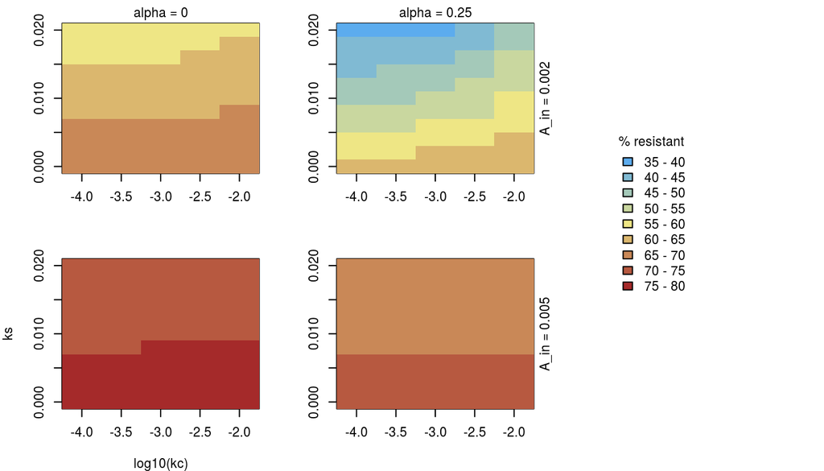

## 6.3 Multi-object models

### 6.3.1 Water-sediment interaction

#### 6.3.1.1 Problem description

The model considers interaction between water column and the underlying bottom sediments (figure below). Both, water column and sediment are treated as being perfectly mixed. A particulate component `x` is transfered from water to sediment via settling and it undergoes degradation in both water and sediment. Degradation releases a dissolved component `s` being subject to diffusive transport across the sediment-water interface. The water column concentrations are also affected by external in-/outflow of `x` and `s`. For the sake of simplicity, the model has no spatial resolution.

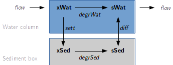

The model is implemented in two versions.

In the **single-object version**, water and sediment compartment are treated together as a single object, resulting in an ordinary, 0-dimensional ODE model. This is the reference implementation producing the ‘exact’ numerical solution. Integration is performed with the default method of [`deSolve`](http://cran.r-project.org/package=deSolve).

In the **multi-object version**, water and sediment are treated as two separate, 0-dimensional objects. Data are exchanged between the two sub-models after predefined time steps. At present, the coupling time step is identical to the output time step (but automatic adjustment would be possible). The dynamic simulation can be performed either with [`deSolve`](http://cran.r-project.org/package=deSolve) or with the `rodeo`-internal ODE solver (see class method `step`).

In general, objects are either linked via state variables or flux rates. In the latter case, a ‘work-share convention’ is required that specifies which object (of the two linked objects) actually computes the flux. In the considered case, it seems reasonable to let the water column object compute the settling flux of `x` and make the sediment object responsible for the diffusive flux of `s`. The linkage between the two objects is fully described by the table below. It specifies which output (source item/type) of which object (source object) supplies the value for a particular parameter in a different object (target).

[output not shown]

#### 6.3.1.2 Single-object version

The tabular model definition, function implementation, R source code, and output of the single-object version follows below.

Declaration of state variables (file ‘vars.txt’).

| name | unit | description |
| --- | --- | --- |
| xWat | mol/m3 | conc. of x in water column |
| xSed | mol/m3 bulk | conc. of x in sediment |
| sWat | mol/m3 | conc. of s in water column |
| sSed | mol/m3 liquid | conc. of s in pore water |

Declaration of parameters (file ‘pars.txt’).

| name | unit | description |
| --- | --- | --- |
| kWat | 1/d | decay constant in water |
| kSed | 1/d | decay constant in sediment |
| kDif | m2/d | diffusion coefficient |
| hDif | m | diffusion distance |
| por | - | porosity of sediment |
| uSet | m/d | effective settling velocity |
| zWat | m | depth of water column |
| zSed | m | thickness of sediment layer |
| vol | m3 | volume of water body |
| s_x | mol/mol | stoichiometric ratio s:x |

Declaration of functions (file ‘funs.txt’).

| name | unit | description |
| --- | --- | --- |
| q | m3/d | flow rate |
| xInf | mM | concentration of x in inflow |
| sInf | mM | concentration of s in inflow |

Definition of process rates (file ‘pros.txt’).

| name | unit | description | expression |
| --- | --- | --- | --- |
| flow | m3/d | flow through water column | q(time)/vol |
| sett | mol/m2/d | settling of x | uSet * xWat |
| diff | mol/m2/d | diffusion at w/s interf. | kDif/hDif * por * (sSed-sWat) |
| degrWat | mol/m3/d | degrad. of x in water | kWat * xWat |
| degrSed | mol/m3/d | degrad. of x in sediment | kSed * xSed |

Definition of stoichiometric factors (file ‘stoi.txt’).

| process | xWat | xSed | sWat | sSed |
| --- | --- | --- | --- | --- |
| flow | (xInf(time)-xWat) | NA | (sInf(time)-sWat) | NA |
| sett | -1/zWat | 1/zSed | NA | NA |
| diff | NA | NA | 1/zWat | -1/zSed/por |
| degrWat | -1 | NA | s_x | NA |
| degrSed | NA | -1 | NA | s_x/por |

```
module functions
 implicit none

 contains

 function q(time) result (res)
   double precision, intent(in):: time
   double precision:: res
   res= 86400d0
 end function

 function xInf(time) result (res)
   double precision, intent(in):: time
   double precision:: res
   res= 10.0d0
 end function

 function sInf(time) result (res)
   double precision, intent(in):: time
   double precision:: res
   res= 0.0d0
 end function

 end module
```

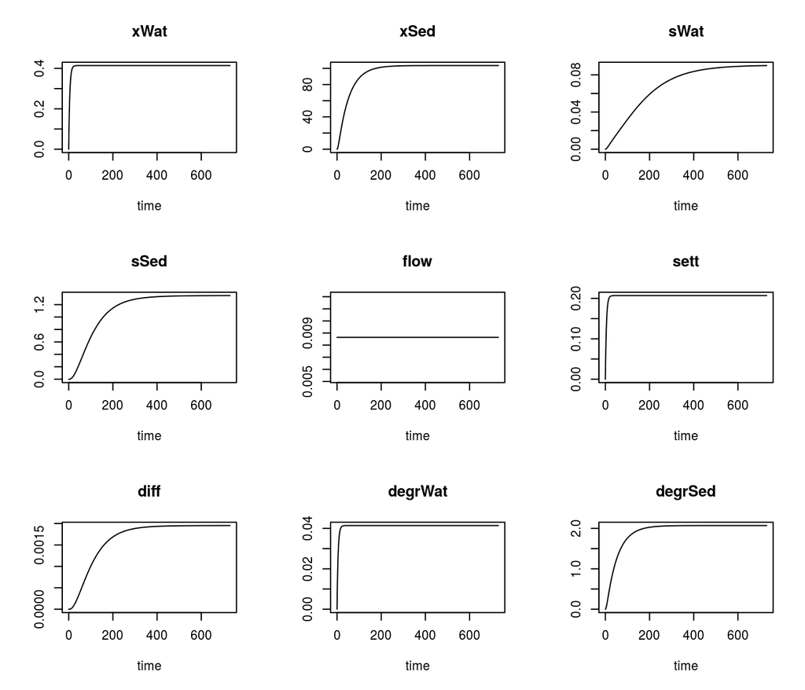

```r
rm(list=ls())

# Adjustable settings ##########################################################
times <- seq(from=0, to=2*365, by=1)                         # Times of interest
pars <- c(kWat=0.1, kSed=0.02, kDif=1e-9*86400, hDif=0.05,   # Parameters
  por=0.9, uSet=0.5, zWat=5, zSed=0.1, vol=10e6, s_x=1/106)
vars <- c(xWat=0, xSed=0, sWat=0, sSed=0)                    # Initial values
# End of settings ##############################################################

# Load packages
library("rodeo")
library("deSolve")

# Initialize rodeo object
rd <- function(f, ...) {read.table(file=paste0("singleObject/",f),
  sep="\t", header=TRUE, ...)}
model <- rodeo$new(
  vars=rd("vars.txt"), pars=rd("pars.txt"), funs=rd("funs.txt"), pros=rd("pros.txt"),
  stoi=as.matrix(rd("stoi.txt", row.names="process")), asMatrix=TRUE, dim=1)

# Assign initial values and parameters
model$setVars(vars)
model$setPars(pars)

# Generate code, compile into shared library, load library
lib <- model$compile("functions.f95")
dyn.load(lib["libFile"])

# Integrate
out <- ode(y=model$getVars(), times=times, func=lib["libFunc"], parms=model$getPars(),
  dllname=lib["libName"], nout=model$lenPros(), outnames=model$namesPros())

# Clean-up
dyn.unload(lib["libFile"])
invisible(file.remove(lib["libFile"]))

# Plot method for deSolve objects
plot(out)
```

#### 6.3.1.3 Multi-object version

In the multi-object version, the objects need to be instantiated from a separate set of tables (shown below). The function implementation does not differ from the above single-object case.

State variables of the water column object (file ‘wat_vars.txt’).

| name | unit | description |
| --- | --- | --- |
| xWat | mol/m3 | conc. of x in water column |
| sWat | mol/m3 | conc. of s in water column |

State variables of the sediment object (file ‘sed_vars.txt’).

| name | unit | description |
| --- | --- | --- |
| xSed | mol/m3 bulk | conc. of x in sediment |
| sSed | mol/m3 liquid | conc. of s in pore water |

Parameters of the water column object (file ‘wat_pars.txt’).

| name | unit | description |
| --- | --- | --- |
| kWat | 1/d | decay constant in water |
| uSet | m/d | effective settling velocity |
| zWat | m | depth of water column |
| vol | m3 | volume of water body |
| s_x | mol/mol | stoichiometric ratio s:x |
| flux_s | mol/m2/d | flux of s accross s/w interface |

Parameters of the sediment object (file ‘sed_pars.txt’).

| name | unit | description |
| --- | --- | --- |
| kSed | 1/d | decay constant in sediment |
| kDif | m2/d | diffusion coefficient |
| hDif | m | diffusion distance |
| por | - | porosity of sediment |
| zSed | m | thickness of sediment layer |
| s_x | mol/mol | stoichiometric ratio s:x |
| flux_x | mol x/m2/d | flux of x across s/w interface |
| sWat | mol/m3 | concentration of s in overlying water |

Functions of the water column object (file ‘wat_funs.txt’).

| name | unit | description |
| --- | --- | --- |
| q | m3/d | flow rate |
| xInf | mM | concentration of x in inflow |
| sInf | mM | concentration of s in inflow |

Functions of the sediment object (file ‘sed_funs.txt’).

| name | unit | description |
| --- | --- | --- |
| dummy | none | dummy function |

Processes of the water column object (file ‘wat_pros.txt’).

| name | unit | description | expression |
| --- | --- | --- | --- |
| flow | m3/d | flow through water column | q(time)/vol |
| sett | mol/m2/d | settling of x | uSet * xWat |
| diff | mol/m2/d | diffusion at w/s interf. | flux_s |
| degrWat | mol/m3/d | degrad. of x in water | kWat * xWat |

Processes of the sediment object (file ‘sed_pros.txt’).

| name | unit | description | expression |
| --- | --- | --- | --- |
| sett | mol/m2/d | settling of x | flux_x |
| diff | mol/m2/d | diffusion at w/s interf. | kDif/hDif * por * (sSed-sWat) |
| degrSed | mol/m3/d | degrad. of x in sediment | kSed * xSed |

Stoichiometry of the water column object (file ‘watstoi.txt’).

| process | xWat | sWat |
| --- | --- | --- |
| flow | (xInf(time)-xWat) | (sInf(time)-sWat) |
| sett | -1/zWat | NA |
| diff | NA | 1/zWat |
| degrWat | -1 | s_x |

Stoichiometry of the sediment object (file ‘sedstoi.txt’).

| process | xSed | sSed |
| --- | --- | --- |
| sett | 1/zSed | NA |
| diff | NA | -1/zSed/por |
| degrSed | -1 | s_x/por |

In the R source code (see below), the two objects are stored in a list to allow for convenient iteration using methods like `lapply`. The code section performing the actual simulation is wrapped into a `system.time()` construct. This can be used to compare the performance of the `deSolve`-based solution with the one based on `rodeo`’s internal ODE solver.

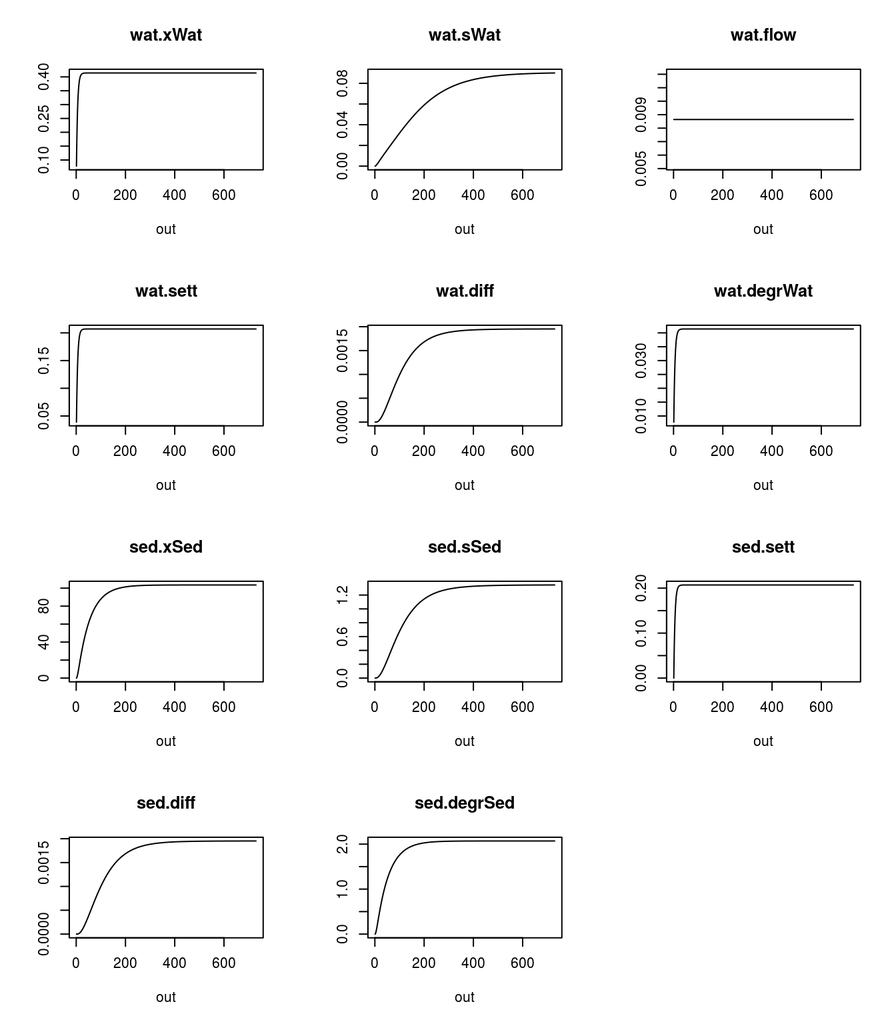

```
##    user  system elapsed
##   0.212   0.000   0.212
```

```r
rm(list=ls())

# Adjustable settings ##########################################################
internal <- TRUE                       # Use internal solver instead of deSolve?
times <- seq(from=0, to=365*2, by=1)   # Times of interest
objects <- c("wat", "sed")             # Object names
pars <- list(                          # Fixed parameters
  wat= c(kWat=0.1, uSet=0.5, zWat=5, vol=10e6, s_x=1/106),
  sed= c(kSed=0.02, kDif=1e-9*86400, hDif=0.05, por=0.9, zSed=0.1, s_x=1/106)
)
vars <- list(                          # Initial values
  wat= c(xWat=0, sWat=0),
  sed= c(xSed=0, sSed=0)
)

# Parameters used for model coupling; these need to be initialized
pars$wat["flux_s"] <- 0
pars$sed["flux_x"] <- 0
pars$sed["sWat"] <- vars$w["sWat"]

# Definition of links between objects
# The value for a parameter in a target object (needs data) is provided by a
# source object (supplier). Supplied is either a state variable or process rate.
links <- rbind(
  link1= c(tarObj="wat", tarPar="flux_s", srcObj="sed", srcItem="diff"),
  link2= c(tarObj="sed", tarPar="flux_x", srcObj="wat", srcItem="sett"),
  link3= c(tarObj="sed", tarPar="sWat",   srcObj="wat", srcItem="sWat")
)
# End of settings ##############################################################

# Load packages
library("rodeo")
library("deSolve")

# Initialize list of rodeo objects
rd <- function(dir,f, ...) {read.table(file=paste0("multiObject/",obj,"_",f),
  sep="\t", header=TRUE, ...)}
models <- list()
for (obj in objects) {
  models[[obj]] <- rodeo$new(
    vars=rd(obj, "vars.txt"), pars=rd(obj, "pars.txt"),
    funs=rd(obj, "funs.txt"), pros=rd(obj, "pros.txt"),
    stoi=as.matrix(rd(obj, "stoi.txt", row.names="process")), asMatrix=TRUE,
    dim=1)
}

# Generate and load Fortran library for selected integrator
if (internal) {
  for (obj in objects)
    models[[obj]]$initStepper(fileFun="functions.f95", method="rk5")
} else {
  lib <- list()
  for (obj in objects) {
    lib[[obj]] <- models[[obj]]$compile("functions.f95")
    dyn.load(lib[[obj]]["libFile"])
  }
}

# Set initial parameters and states
invisible(lapply(setNames(objects, objects),
  function(obj) {models[[obj]]$setVars(vars[[obj]])}))
invisible(lapply(setNames(objects, objects),
  function(obj) {models[[obj]]$setPars(pars[[obj]])}))

# Function to update parameters of a particular object using the linkage table
# Inputs:
#   objPar: Parameters of a particular target object (numeric vector)
#   outAll:  States and process rates of all objects (list of numeric vectors)
#   links:   Object linkage table (matrix of type character)
# Returns: objPar after updating of values
updatePars <- function (objPar, outAll, links) {
  if (nrow(links) > 0) {
    f <- function(i) {
      objPar[links[i,"tarPar"]] <<- outAll[[links[i,"srcObj"]]][links[i,"srcItem"]]
      NULL
    }
    lapply(1:nrow(links), f)
  }
  objPar
}

# Wrapper for integration methods
integr <- function(obj, t0, t1, models, internal, lib, check) {
  if (internal) {
    tmp <- models[[obj]]$step(t0, h=t1-t0, check=check)
  } else {
    tmp <- deSolve::ode(y=models[[obj]]$getVars(), times=c(t0, t1),
      func=lib[[obj]]["libFunc"], parms=models[[obj]]$getPars(),
      dllname=lib[[obj]]["libName"],
      nout=models[[obj]]$lenPros())
    tmp <- tmp[2,2:ncol(tmp)]
  }
  names(tmp) <- c(models[[obj]]$namesVars(), models[[obj]]$namesPros())
  tmp
}

# Function to simulate coupled models over a single time step
advance <- function(objects, t0, t1, models, internal, lib, check) {
  out <- list()
  # Call integrator
  out <- lapply(objects, integr, t0=t0, t1=t1, models=models, internal=internal,
    lib=lib, check=check)
  names(out) <- objects
  # Update parameters affected by coupling
  lapply(setNames(objects, objects),
    function(obj) {models[[obj]]$setPars(
    updatePars(models[[obj]]$getPars(useNames=TRUE), out, links[links[,"tarObj"]==obj,,drop=FALSE]))})
  # Re-initialize state variables
  lapply(setNames(objects, objects),
    function(obj) {models[[obj]]$setVars(out[[obj]][models[[obj]]$namesVars()])})
  return(out)
}

# Loop over time steps
system.time({
for (i in 1:(length(times)-1)) {
  # Simulate
  out <- advance(objects=objects, t0=times[i], t1=times[i+1],
    models=models, internal=internal, lib=lib, check=(i==1))
  # Store outputs as a matrix
  if (i == 1) {
    res <- lapply(setNames(objects, objects),
      function(obj) {out[[obj]]})
  } else {
    res <- lapply(setNames(objects, objects),
      function(obj) {rbind(res[[obj]], out[[obj]])})
  }
}
})

# Clean-up
if (!internal) {
  for (obj in objects) {
    dyn.unload(lib[[obj]]["libFile"])
    invisible(file.remove(lib[[obj]]["libFile"]))
  }
}

# Plot
out <- c(time= times[2:length(times)])
for (obj in objects) {
  colnames(res[[obj]]) <- paste(obj, colnames(res[[obj]]), sep=".")
  out <- cbind(out, res[[obj]])
}
class(out) <- "deSolve"
plot(out, mfrow=c(4,3))
```

The above graphical output from the multi-object version shows good agreement with the reference (i. e. the output of the single-object version). This finding, however, is not universal and the mismatch can be large for other models depending on the frequency of inter-model communication.

References

Bronstert, A., P. Schmitt, E. J. Plate, and J. Wald. 1991. “A Physically Based Distributed Watershed Model to Simulate Floods and Flood Protection Measures in a Flat Area with Shallow Ground Water Table.” International Association for Hydraulic Research, XXIV Congress, Madrid, Spain.

Chen, Z., Y. Zhang, Y. Gao, S. A. Boyd, D. Zhu, and H. Li. 2015. “Influence of Dissolved Organic Matter on Tetracycline Bioavailability to an Antibiotic-Resistant Bacterium.” *Environmental Science and Technology* 49: 10903–10.

Elgeti, K. 1996. “A New Equation for Correlating a Pipe Flow Reactor with a Cascade of Mixed Reactors.” *Chemical Engineering Science* 51 (23): 5077–80.

Gregersen, J. B., P. J. A. Gijsbers, and S. J. P. Westen. 2007. “OpenMI: Open Modelling Interface.” *Journal of Hydroinformatics* 9 (3): 175–91.

Hellweger, F. L., X. Ruan, and S. Sanchez. 2011. “A Simple Model of Tetracycline Antibiotic Resistance in the Aquatic Environment (with Application to the Poudre River).” *Int. J. Environ. Res. Public Health* 8 (2): 480–97.

Kinzelbach, W. 1986. “Groundwater Modelling - an Introduction with Sample Programs in BASIC.” In *Developments in Water Science*. Vol. 25. Elsevier.

Kinzelbach, W., and R. Rausch. 1995. *Grundwassermodellierung*. Gebrüder Bornträger, Stuttgart.

Lenski, R. E. 1998. “Bacterial Evolution and the Cost of Antibiotic Resistance.” *International Microbiology* 1: 265–70.

Rauch, W. 1993. “Über Die Hydraulische Wechselwirkung von Oberflächengewässern Und Grundwasserkörpern.” *Wasserwirtschaft* 83: 14–18.

Streeter, W. H., and W. B. Phelps. 1925. “A Study of the Pollution and Natural Purification of the Ohio River.” Public Health Bull. 146, US Public Health Service, Washington DC.

Tolls, J. 2001. “Sorption of Veterinary Pharmaceuticals in Soils: A Review.” *Environmental Science and Technology* 35 (17): 3397–3406.

Wammer, K.H., M.T. Slattery, A.M. Stemig, and J.L. Ditty. 2011. “Tetracycline Photolysis in Natural Waters: Loss of Antibacterial Activity.” *Chemosphere* 85 (9): 1505–10.